# Panorama de l’état de la malnutrition dans le monde

# I. Exploration et préparation des données

## 1.1 Fichier disponibilité alimentaire pour l’année 2013

- Le pays.
- Le produit.
- 4 variables de disponibilité alimentaire.
- 10 variables qui précisent les utilisations/moyens d’acquisition de la disponibilité alimentaire. Elles sont toutes exprimées en milliers de tonnes.
- Enfin, une variable type qui précise si le produit est d’origine animale ou végétale.

```python
import pandas as pd
```

```python
dispo_alimentaire = pd.read_csv('dispo_alimentaire.csv')
```

```python
dispo_alimentaire.head()
```

|  | Zone | Produit | Origine | Aliments pour animaux | Autres Utilisations | Disponibilité alimentaire (Kcal/personne/jour) | Disponibilité alimentaire en quantité (kg/personne/an) | Disponibilité de matière grasse en quantité (g/personne/jour) | Disponibilité de protéines en quantité (g/personne/jour) | Disponibilité intérieure | Exportations - Quantité | Importations - Quantité | Nourriture | Pertes | Production | Semences | Traitement | Variation de stock |
| --- | --- | --- | --- | --- | --- | --- | --- | --- | --- | --- | --- | --- | --- | --- | --- | --- | --- | --- |
| 0 | Afghanistan | Abats Comestible | animale | NaN | NaN | 5.0 | 1.72 | 0.20 | 0.77 | 53.0 | NaN | NaN | 53.0 | NaN | 53.0 | NaN | NaN | NaN |
| 1 | Afghanistan | Agrumes, Autres | vegetale | NaN | NaN | 1.0 | 1.29 | 0.01 | 0.02 | 41.0 | 2.0 | 40.0 | 39.0 | 2.0 | 3.0 | NaN | NaN | NaN |
| 2 | Afghanistan | Aliments pour enfants | vegetale | NaN | NaN | 1.0 | 0.06 | 0.01 | 0.03 | 2.0 | NaN | 2.0 | 2.0 | NaN | NaN | NaN | NaN | NaN |
| 3 | Afghanistan | Ananas | vegetale | NaN | NaN | 0.0 | 0.00 | NaN | NaN | 0.0 | NaN | 0.0 | 0.0 | NaN | NaN | NaN | NaN | NaN |
| 4 | Afghanistan | Bananes | vegetale | NaN | NaN | 4.0 | 2.70 | 0.02 | 0.05 | 82.0 | NaN | 82.0 | 82.0 | NaN | NaN | NaN | NaN | NaN |

```python
dispo_alimentaire.dtypes
```

```
Zone                                                              object
Produit                                                           object
Origine                                                           object
Aliments pour animaux                                            float64
Autres Utilisations                                              float64
Disponibilité alimentaire (Kcal/personne/jour)                   float64
Disponibilité alimentaire en quantité (kg/personne/an)           float64
Disponibilité de matière grasse en quantité (g/personne/jour)    float64
Disponibilité de protéines en quantité (g/personne/jour)         float64
Disponibilité intérieure                                         float64
Exportations - Quantité                                          float64
Importations - Quantité                                          float64
Nourriture                                                       float64
Pertes                                                           float64
Production                                                       float64
Semences                                                         float64
Traitement                                                       float64
Variation de stock                                               float64
dtype: object
```

```python
dispo_alimentaire.shape
```

```
(15605, 18)
```

```python
dispo_alimentaire.describe(include = 'all')
```

|  | Zone | Produit | Origine | Aliments pour animaux | Autres Utilisations | Disponibilité alimentaire (Kcal/personne/jour) | Disponibilité alimentaire en quantité (kg/personne/an) | Disponibilité de matière grasse en quantité (g/personne/jour) | Disponibilité de protéines en quantité (g/personne/jour) | Disponibilité intérieure | Exportations - Quantité | Importations - Quantité | Nourriture | Pertes | Production | Semences | Traitement | Variation de stock |
| --- | --- | --- | --- | --- | --- | --- | --- | --- | --- | --- | --- | --- | --- | --- | --- | --- | --- | --- |
| count | 15605 | 15605 | 15605 | 2720.000000 | 5496.000000 | 14241.000000 | 14015.000000 | 11794.000000 | 11561.000000 | 15382.000000 | 12226.000000 | 14852.000000 | 14015.000000 | 4278.000000 | 9180.000000 | 2091.000000 | 2292.000000 | 6776.000000 |
| unique | 174 | 98 | 2 | NaN | NaN | NaN | NaN | NaN | NaN | NaN | NaN | NaN | NaN | NaN | NaN | NaN | NaN | NaN |
| top | Inde | Fruits, Autres | vegetale | NaN | NaN | NaN | NaN | NaN | NaN | NaN | NaN | NaN | NaN | NaN | NaN | NaN | NaN | NaN |
| freq | 97 | 174 | 11896 | NaN | NaN | NaN | NaN | NaN | NaN | NaN | NaN | NaN | NaN | NaN | NaN | NaN | NaN | NaN |
| mean | NaN | NaN | NaN | 479.501838 | 157.391376 | 34.789832 | 8.719368 | 1.283111 | 1.223608 | 640.293460 | 110.596925 | 87.264543 | 347.931359 | 106.053763 | 1090.379085 | 73.974653 | 961.905323 | -15.407615 |
| std | NaN | NaN | NaN | 4240.119637 | 5076.785816 | 107.287655 | 24.618223 | 3.680399 | 3.598686 | 9067.267153 | 1053.318990 | 717.372714 | 4475.704458 | 1113.100416 | 12067.344094 | 528.069224 | 10381.795904 | 549.834540 |
| min | NaN | NaN | NaN | 0.000000 | 0.000000 | -21.000000 | -1.930000 | -0.030000 | -0.370000 | -3430.000000 | -41.000000 | -201.000000 | -246.000000 | 0.000000 | 0.000000 | 0.000000 | -19.000000 | -39863.000000 |
| 25% | NaN | NaN | NaN | 0.000000 | 0.000000 | 0.000000 | 0.060000 | 0.010000 | 0.010000 | 0.000000 | 0.000000 | 0.000000 | 0.000000 | 0.000000 | 2.000000 | 0.000000 | 0.000000 | 0.000000 |
| 50% | NaN | NaN | NaN | 4.000000 | 0.000000 | 4.000000 | 0.830000 | 0.080000 | 0.100000 | 7.000000 | 0.000000 | 2.000000 | 5.000000 | 4.000000 | 22.000000 | 2.000000 | 6.000000 | 0.000000 |
| 75% | NaN | NaN | NaN | 74.000000 | 4.000000 | 21.000000 | 5.190000 | 0.630000 | 0.660000 | 76.750000 | 9.000000 | 18.000000 | 52.000000 | 26.000000 | 191.250000 | 17.000000 | 69.000000 | 0.000000 |
| max | NaN | NaN | NaN | 150000.000000 | 347309.000000 | 1711.000000 | 430.760000 | 60.760000 | 54.970000 | 739267.000000 | 42797.000000 | 63381.000000 | 426850.000000 | 55047.000000 | 739267.000000 | 17060.000000 | 326711.000000 | 5284.000000 |

```python
dispo_alimentaire.info()
```

```
<class 'pandas.core.frame.DataFrame'>
RangeIndex: 15605 entries, 0 to 15604
Data columns (total 18 columns):
 #   Column                                                         Non-Null Count  Dtype
---  ------                                                         --------------  -----
 0   Zone                                                           15605 non-null  object
 1   Produit                                                        15605 non-null  object
 2   Origine                                                        15605 non-null  object
 3   Aliments pour animaux                                          2720 non-null   float64
 4   Autres Utilisations                                            5496 non-null   float64
 5   Disponibilité alimentaire (Kcal/personne/jour)                 14241 non-null  float64
 6   Disponibilité alimentaire en quantité (kg/personne/an)         14015 non-null  float64
 7   Disponibilité de matière grasse en quantité (g/personne/jour)  11794 non-null  float64
 8   Disponibilité de protéines en quantité (g/personne/jour)       11561 non-null  float64
 9   Disponibilité intérieure                                       15382 non-null  float64
 10  Exportations - Quantité                                        12226 non-null  float64
 11  Importations - Quantité                                        14852 non-null  float64
 12  Nourriture                                                     14015 non-null  float64
 13  Pertes                                                         4278 non-null   float64
 14  Production                                                     9180 non-null   float64
 15  Semences                                                       2091 non-null   float64
 16  Traitement                                                     2292 non-null   float64
 17  Variation de stock                                             6776 non-null   float64
dtypes: float64(15), object(3)
memory usage: 2.1+ MB
```

```python
dispo_alimentaire.isnull().mean()
```

```
Zone                                                             0.000000
Produit                                                          0.000000
Origine                                                          0.000000
Aliments pour animaux                                            0.825697
Autres Utilisations                                              0.647805
Disponibilité alimentaire (Kcal/personne/jour)                   0.087408
Disponibilité alimentaire en quantité (kg/personne/an)           0.101890
Disponibilité de matière grasse en quantité (g/personne/jour)    0.244217
Disponibilité de protéines en quantité (g/personne/jour)         0.259148
Disponibilité intérieure                                         0.014290
Exportations - Quantité                                          0.216533
Importations - Quantité                                          0.048254
Nourriture                                                       0.101890
Pertes                                                           0.725857
Production                                                       0.411727
Semences                                                         0.866004
Traitement                                                       0.853124
Variation de stock                                               0.565780
dtype: float64
```

```python
doublons_dispo = dispo_alimentaire.duplicated()
```

```python
doublons_dispo.value_counts()
```

```
False    15605
dtype: int64
```

## 1.2 Modification type des variables

```python
def object_to_category(df, columns) :
    for column in columns :
        df[column] = df[column].astype("category")
```

```python
object_to_category(dispo_alimentaire, ["Zone", "Produit", "Origine"])
```

```python
dispo_alimentaire.dtypes
```

```
Zone                                                             category
Produit                                                          category
Origine                                                          category
Aliments pour animaux                                             float64
Autres Utilisations                                               float64
Disponibilité alimentaire (Kcal/personne/jour)                    float64
Disponibilité alimentaire en quantité (kg/personne/an)            float64
Disponibilité de matière grasse en quantité (g/personne/jour)     float64
Disponibilité de protéines en quantité (g/personne/jour)          float64
Disponibilité intérieure                                          float64
Exportations - Quantité                                           float64
Importations - Quantité                                           float64
Nourriture                                                        float64
Pertes                                                            float64
Production                                                        float64
Semences                                                          float64
Traitement                                                        float64
Variation de stock                                                float64
dtype: object
```

## 2.1 Fichier insécurité alimentaire

- Le pays.
- Intervalle d’années.
- Le nombre de personnes en sous-alimentation en millions d’habitants (ex. : pour l’intervalle 2012-2014, le nombre de personnes correspond à la moyenne sur ces 3 années, on peut le résumer en 2013).

```python
insecurite_alimentaire = pd.read_csv('sous_nutrition.csv')
```

```python
insecurite_alimentaire.head()
```

|  | Zone | Année | Valeur |
| --- | --- | --- | --- |
| 0 | Afghanistan | 2012-2014 | 8.6 |
| 1 | Afghanistan | 2013-2015 | 8.8 |
| 2 | Afghanistan | 2014-2016 | 8.9 |
| 3 | Afghanistan | 2015-2017 | 9.7 |
| 4 | Afghanistan | 2016-2018 | 10.5 |

```python
insecurite_alimentaire.dtypes
```

```
Zone      object
Année     object
Valeur    object
dtype: object
```

```python
insecurite_alimentaire.shape
```

```
(1218, 3)
```

```python
insecurite_alimentaire.describe(include = 'all')
```

|  | Zone | Année | Valeur |
| --- | --- | --- | --- |
| count | 1218 | 1218 | 624 |
| unique | 203 | 6 | 139 |
| top | Bélarus | 2016-2018 | <0.1 |
| freq | 6 | 203 | 120 |

```python
insecurite_alimentaire.info()
```

```
<class 'pandas.core.frame.DataFrame'>
RangeIndex: 1218 entries, 0 to 1217
Data columns (total 3 columns):
 #   Column  Non-Null Count  Dtype
---  ------  --------------  -----
 0   Zone    1218 non-null   object
 1   Année   1218 non-null   object
 2   Valeur  624 non-null    object
dtypes: object(3)
memory usage: 28.7+ KB
```

```python
insecurite_alimentaire.isnull().mean()
```

```
Zone      0.000000
Année     0.000000
Valeur    0.487685
dtype: float64
```

```python
doublons_insecu = insecurite_alimentaire.duplicated()
```

```python
doublons_insecu.value_counts()
```

```
False    1218
dtype: int64
```

## 2.2 Modification type des variables et unités

```python
object_to_category(insecurite_alimentaire, ["Zone"])
```

```python
insecurite_alimentaire.dtypes
```

```
Zone      category
Année       object
Valeur      object
dtype: object
```

```python
#conversion de l'unité pour la variable valeur :
insecurite_alimentaire["Valeur"] = pd.to_numeric(insecurite_alimentaire["Valeur"], errors='coerce')*1000000
```

```python
insecurite_alimentaire["Valeur"]
```

```
0        8600000.0
1        8800000.0
2        8900000.0
3        9700000.0
4       10500000.0
           ...
1213           NaN
1214           NaN
1215           NaN
1216           NaN
1217           NaN
Name: Valeur, Length: 1218, dtype: float64
```

```python
insecurite_alimentaire.dtypes
```

```
Zone      category
Année       object
Valeur     float64
dtype: object
```

```python
insecurite_alimentaire["Année"].unique()
```

```
array(['2012-2014', '2013-2015', '2014-2016', '2015-2017', '2016-2018',
       '2017-2019'], dtype=object)
```

```python
def split_years (row) :
    row = row.split("-")
    row = row[0]
    row = pd.to_numeric(row)
    row = row + 1
    return row
```

```python
insecurite_alimentaire["Année"] = insecurite_alimentaire["Année"].apply(split_years)
```

```python
insecurite_alimentaire["Année"]
```

```
0       2013
1       2014
2       2015
3       2016
4       2017
        ...
1213    2014
1214    2015
1215    2016
1216    2017
1217    2018
Name: Année, Length: 1218, dtype: int64
```

```python
insecurite_alimentaire.groupby("Année")["Valeur"].sum()
```

```
Année
2013    528100000.0
2014    523500000.0
2015    524700000.0
2016    528600000.0
2017    535700000.0
2018    544200000.0
Name: Valeur, dtype: float64
```

## 3. Fichier population

- Le pays.
- L’année.
- La population du pays, exprimée en milliers d’habitants.

```python
population = pd.read_csv('population.csv')
```

```python
population.head()
```

|  | Zone | Année | Valeur |
| --- | --- | --- | --- |
| 0 | Afghanistan | 2013 | 32269.589 |
| 1 | Afghanistan | 2014 | 33370.794 |
| 2 | Afghanistan | 2015 | 34413.603 |
| 3 | Afghanistan | 2016 | 35383.032 |
| 4 | Afghanistan | 2017 | 36296.113 |

```python
population.dtypes
```

```
Zone       object
Année       int64
Valeur    float64
dtype: object
```

```python
population.shape
```

```
(1416, 3)
```

```python
population.describe(include = 'all')
```

|  | Zone | Année | Valeur |
| --- | --- | --- | --- |
| count | 1416 | 1416.000000 | 1.416000e+03 |
| unique | 236 | NaN | NaN |
| top | Bélarus | NaN | NaN |
| freq | 6 | NaN | NaN |
| mean | NaN | 2015.500000 | 3.144793e+04 |
| std | NaN | 1.708428 | 1.300812e+05 |
| min | NaN | 2013.000000 | 7.930000e-01 |
| 25% | NaN | 2014.000000 | 3.783410e+02 |
| 50% | NaN | 2015.500000 | 5.126480e+03 |
| 75% | NaN | 2017.000000 | 1.930666e+04 |
| max | NaN | 2018.000000 | 1.427648e+06 |

```python
population.info()
```

```
<class 'pandas.core.frame.DataFrame'>
RangeIndex: 1416 entries, 0 to 1415
Data columns (total 3 columns):
 #   Column  Non-Null Count  Dtype
---  ------  --------------  -----
 0   Zone    1416 non-null   object
 1   Année   1416 non-null   int64
 2   Valeur  1416 non-null   float64
dtypes: float64(1), int64(1), object(1)
memory usage: 33.3+ KB
```

```python
population.isnull().mean()
```

```
Zone      0.0
Année     0.0
Valeur    0.0
dtype: float64
```

```python
doublons_population= population.duplicated()
```

```python
doublons_population.value_counts()
```

```
False    1416
dtype: int64
```

## 3.2 Modification type de variable et unité population

```python
object_to_category(population, ["Zone"])
```

```python
population.dtypes
```

```
Zone      category
Année        int64
Valeur     float64
dtype: object
```

```python
population["Valeur"] = population["Valeur"]*1000
```

## 4.1 Fichier aide alimentaire

- Le pays bénéficiaire.
- L’année.
- Le produit.
- La quantité qui a été donnée comme aide alimentaire, en tonnes.

```python
aide_alimentaire = pd.read_csv('aide_alimentaire.csv')
```

```python
aide_alimentaire.head()
```

|  | Pays bénéficiaire | Année | Produit | Valeur |
| --- | --- | --- | --- | --- |
| 0 | Afghanistan | 2013 | Autres non-céréales | 682 |
| 1 | Afghanistan | 2014 | Autres non-céréales | 335 |
| 2 | Afghanistan | 2013 | Blé et Farin | 39224 |
| 3 | Afghanistan | 2014 | Blé et Farin | 15160 |
| 4 | Afghanistan | 2013 | Céréales | 40504 |

```python
aide_alimentaire.dtypes
```

```
Pays bénéficiaire    object
Année                 int64
Produit              object
Valeur                int64
dtype: object
```

```python
aide_alimentaire.shape
```

```
(1475, 4)
```

```python
aide_alimentaire.describe(include = 'all')
```

|  | Pays bénéficiaire | Année | Produit | Valeur |
| --- | --- | --- | --- | --- |
| count | 1475 | 1475.000000 | 1475 | 1475.000000 |
| unique | 76 | NaN | 16 | NaN |
| top | Algérie | NaN | Non-céréales | NaN |
| freq | 39 | NaN | 220 | NaN |
| mean | NaN | 2014.054237 | NaN | 7481.966780 |
| std | NaN | 0.946916 | NaN | 23339.531424 |
| min | NaN | 2013.000000 | NaN | 0.000000 |
| 25% | NaN | 2013.000000 | NaN | 287.500000 |
| 50% | NaN | 2014.000000 | NaN | 1178.000000 |
| 75% | NaN | 2015.000000 | NaN | 4334.500000 |
| max | NaN | 2016.000000 | NaN | 265013.000000 |

```python
aide_alimentaire.info()
```

```
<class 'pandas.core.frame.DataFrame'>
RangeIndex: 1475 entries, 0 to 1474
Data columns (total 4 columns):
 #   Column             Non-Null Count  Dtype
---  ------             --------------  -----
 0   Pays bénéficiaire  1475 non-null   object
 1   Année              1475 non-null   int64
 2   Produit            1475 non-null   object
 3   Valeur             1475 non-null   int64
dtypes: int64(2), object(2)
memory usage: 46.2+ KB
```

```python
aide_alimentaire.isnull().mean()
```

```
Pays bénéficiaire    0.0
Année                0.0
Produit              0.0
Valeur               0.0
dtype: float64
```

```python
doublons_aide= aide_alimentaire.duplicated()
```

```python
doublons_aide.value_counts()
```

```
False    1475
dtype: int64
```

```python
aide_alimentaire.groupby("Année")["Valeur"].sum()
```

```
Année
2013    4165674
2014    3939152
2015    2187507
2016     743568
Name: Valeur, dtype: int64
```

## 4.2 Modification type des variables et nom variable

```python
object_to_category(aide_alimentaire, ["Pays bénéficiaire", "Produit"])
```

```python
aide_alimentaire.dtypes
```

```
Pays bénéficiaire    category
Année                   int64
Produit              category
Valeur                  int64
dtype: object
```

```python
aide_alimentaire = aide_alimentaire.rename(columns={"Pays bénéficiaire":"Zone"})
aide_alimentaire
```

|  | Zone | Année | Produit | Valeur |
| --- | --- | --- | --- | --- |
| 0 | Afghanistan | 2013 | Autres non-céréales | 682 |
| 1 | Afghanistan | 2014 | Autres non-céréales | 335 |
| 2 | Afghanistan | 2013 | Blé et Farin | 39224 |
| 3 | Afghanistan | 2014 | Blé et Farin | 15160 |
| 4 | Afghanistan | 2013 | Céréales | 40504 |
| ... | ... | ... | ... | ... |
| 1470 | Zimbabwe | 2015 | Mélanges et préparations | 96 |
| 1471 | Zimbabwe | 2013 | Non-céréales | 5022 |
| 1472 | Zimbabwe | 2014 | Non-céréales | 2310 |
| 1473 | Zimbabwe | 2015 | Non-céréales | 306 |
| 1474 | Zimbabwe | 2013 | Riz, total | 64 |

1475 rows × 4 columns

# II. Analyse des données

## 1 Proportion de personnes en état de sous-nutrition

Utilisation des df population et insecurité alimentaire, masques sur l'année 2017 sommes, calcul de pourcentage

```python
#masque sur la valeur 2017 :
population_2017 = population[population["Année"]==2017]
```

```python
sum_population_2017 = population_2017["Valeur"].sum()
```

```python
insecurite_alimentaire_2017 = insecurite_alimentaire[insecurite_alimentaire["Année"] == 2017]
```

```python
sum_insecurite_alimentaire_2017 = insecurite_alimentaire_2017["Valeur"].sum()
```

```python
proportion_sous_nutrition_2017 = sum_insecurite_alimentaire_2017 / sum_population_2017 * 100
```

```python
sum_insecurite_alimentaire_2017
print(f'Le nombre de personnes en état de sous-nutrition en 2017 est de : {round(sum_insecurite_alimentaire_2017)}')
proportion_sous_nutrition_2017
print(f'La proportion de personnes en état de sous-nutrition en 2017 est de : {round(proportion_sous_nutrition_2017,2)}%')
```

```
Le nombre de personnes en état de sous-nutrition en 2017 est de : 535700000
La proportion de personnes en état de sous-nutrition en 2017 est de : 7.1%
```

## 2 Nombre théorique de personnes qui pourraient être nourries à partir de la disponibilité alimentaire mondiale (2017)

● Pour cette analyse, on considerera que l'apport journalier par personne est de 2400 Kcal par personne et par jour. Source : https://www.senat.fr/rap/l98-129/l98-12910.html

utlisation des df dispo_alimentaire, population, comparaison des listes "Zone", corrections, création des deux tables pivot, merge, calcul de la disponibilité alimentaire totale(kcal/pers/jour/pays * population, division par l'apport nécessaire en calories par personne par jour

```python
nbr_calorie_needed_perperson_perday = 2400
```

```python
dispo_alimentaire.head()
```

|  | Zone | Produit | Origine | Aliments pour animaux | Autres Utilisations | Disponibilité alimentaire (Kcal/personne/jour) | Disponibilité alimentaire en quantité (kg/personne/an) | Disponibilité de matière grasse en quantité (g/personne/jour) | Disponibilité de protéines en quantité (g/personne/jour) | Disponibilité intérieure | Exportations - Quantité | Importations - Quantité | Nourriture | Pertes | Production | Semences | Traitement | Variation de stock |
| --- | --- | --- | --- | --- | --- | --- | --- | --- | --- | --- | --- | --- | --- | --- | --- | --- | --- | --- |
| 0 | Afghanistan | Abats Comestible | animale | NaN | NaN | 5.0 | 1.72 | 0.20 | 0.77 | 53.0 | NaN | NaN | 53.0 | NaN | 53.0 | NaN | NaN | NaN |
| 1 | Afghanistan | Agrumes, Autres | vegetale | NaN | NaN | 1.0 | 1.29 | 0.01 | 0.02 | 41.0 | 2.0 | 40.0 | 39.0 | 2.0 | 3.0 | NaN | NaN | NaN |
| 2 | Afghanistan | Aliments pour enfants | vegetale | NaN | NaN | 1.0 | 0.06 | 0.01 | 0.03 | 2.0 | NaN | 2.0 | 2.0 | NaN | NaN | NaN | NaN | NaN |
| 3 | Afghanistan | Ananas | vegetale | NaN | NaN | 0.0 | 0.00 | NaN | NaN | 0.0 | NaN | 0.0 | 0.0 | NaN | NaN | NaN | NaN | NaN |
| 4 | Afghanistan | Bananes | vegetale | NaN | NaN | 4.0 | 2.70 | 0.02 | 0.05 | 82.0 | NaN | 82.0 | 82.0 | NaN | NaN | NaN | NaN | NaN |

```python
#méthode groupby :
#dispo_alimentaire.groupby("Zone")["Disponibilité alimentaire (Kcal/personne/jour)"].sum()
```

```python
#méthode pivot sur le df disponibilité alimentaire :
calories_2013_perperson_perday_perzone_pivot = dispo_alimentaire.pivot_table(values = "Disponibilité alimentaire (Kcal/personne/jour)", index = "Zone", aggfunc=sum)
calories_2013_perperson_perday_perzone_pivot
```

| Zone | Disponibilité alimentaire (Kcal/personne/jour) |
| --- | --- |
| Afghanistan | 2087.0 |
| Afrique du Sud | 3020.0 |
| Albanie | 3188.0 |
| Algérie | 3293.0 |
| Allemagne | 3503.0 |
| ... | ... |
| Émirats arabes unis | 3275.0 |
| Équateur | 2346.0 |
| États-Unis d'Amérique | 3682.0 |
| Éthiopie | 2129.0 |
| Îles Salomon | 2383.0 |

174 rows × 1 columns

```python
calories_2013_perperson_perday_perzone_pivot.info()
```

```
<class 'pandas.core.frame.DataFrame'>
CategoricalIndex: 174 entries, Afghanistan to Îles Salomon
Data columns (total 1 columns):
 #   Column                                          Non-Null Count  Dtype
---  ------                                          --------------  -----
 0   Disponibilité alimentaire (Kcal/personne/jour)  174 non-null    float64
dtypes: float64(1)
memory usage: 7.1 KB
```

```python
#réduction df population sur les valeurs 2017 :
is_2017_population = population["Année"] == 2017
population_2017 =  population[is_2017_population]
population_2017.head()
```

|  | Zone | Année | Valeur |
| --- | --- | --- | --- |
| 4 | Afghanistan | 2017 | 36296113.0 |
| 10 | Afrique du Sud | 2017 | 57009756.0 |
| 16 | Albanie | 2017 | 2884169.0 |
| 22 | Algérie | 2017 | 41389189.0 |
| 28 | Allemagne | 2017 | 82658409.0 |

```python
#comparaison des valeurs "Zones" entre le df disponibilité alimentaire et le df population :
liste_zones_dispo_alimentaire = calories_2013_perperson_perday_perzone_pivot.index.tolist()
```

```python
liste_zone_population_2017 = population_2017["Zone"].tolist()
```

```python
#il y a un plus grand nombre de valeurs "Zone" dans le df population que dans le df disponibilité alimentaire. Réduction du nombre de valeurs "Zone" du df population pour correspondre aux valeurs du df disponibilité alimentaire :
is_population_2017_reduction_zones = population_2017["Zone"].isin(liste_zones_dispo_alimentaire)
population_2017_reduction_zones= population_2017[is_population_2017_reduction_zones]
zones_population_2017_reduit = population_2017_reduction_zones["Zone"]
liste_zones_population_2017_reduit = zones_population_2017_reduit.tolist()
len(liste_zones_population_2017_reduit)
```

```
172
```

```python
#174 vs 172 : 2 pays de la liste "liste_zones_dispo_alimentaire" n'ont pas été retrouvés, lesquels ? :
set(liste_zones_dispo_alimentaire) - set(liste_zones_population_2017_reduit)
```

```
{'Royaume-Uni', 'Tchéquie (la)'}
```

```python
#correction des différence orthographiques :
population_2017 = population_2017.replace(to_replace = "Royaume-Uni de Grande-Bretagne et d'Irlande du Nord", value="Royaume-Uni" )
population_2017 = population_2017.replace(to_replace = "Tchéquie", value="Tchéquie (la)" )
```

```python
#vérification des corrections :
liste_zone_population2 = population_2017["Zone"].tolist()
```

```python
#réduction du nombre de valeurs "Zone" du df population modifié pour correspondre aux valeurs du df disponibilité alimentaire :
is_population_2017_reduction_zones = population_2017["Zone"].isin(liste_zones_dispo_alimentaire)
population_2017_reduction_zones= population_2017[is_population_2017_reduction_zones]
```

```python
zones_population_2017_reduit = population_2017_reduction_zones["Zone"]
```

```python
#il faut également modifier le nombre de categories (ici 236) afin de pouvoir effecter un merge (mêmes catégories requises entre les 2 df) :
zones_population_2017_reduit= zones_population_2017_reduit.cat.remove_unused_categories()
```

```python
#création d'un dataframe avec le nouveau series zones_population_2017_reduit :
population_2017_reduction_zones_cat =  pd.concat([zones_population_2017_reduit, population_2017_reduction_zones['Valeur'] ], axis=1)
```

```python
#méthode pivot sur le df population_2017_reduction_zones_cat :
population_2017_reduction_zones_pivot = population_2017_reduction_zones_cat.pivot_table(values = "Valeur", index = "Zone")
population_2017_reduction_zones_pivot
```

| Zone | Valeur |
| --- | --- |
| Afghanistan | 36296113.0 |
| Afrique du Sud | 57009756.0 |
| Albanie | 2884169.0 |
| Algérie | 41389189.0 |
| Allemagne | 82658409.0 |
| ... | ... |
| Émirats arabes unis | 9487203.0 |
| Équateur | 16785361.0 |
| États-Unis d'Amérique | 325084756.0 |
| Éthiopie | 106399924.0 |
| Îles Salomon | 636039.0 |

174 rows × 1 columns

```python
#fusion des deux tables pivot population 2017 et calories 2013 :
total_calories_perday_percountry_merge = pd.merge(calories_2013_perperson_perday_perzone_pivot, population_2017_reduction_zones_pivot, on = "Zone")
total_calories_perday_percountry_merge
```

| Zone | Disponibilité alimentaire (Kcal/personne/jour) | Valeur |
| --- | --- | --- |
| Afghanistan | 2087.0 | 36296113.0 |
| Afrique du Sud | 3020.0 | 57009756.0 |
| Albanie | 3188.0 | 2884169.0 |
| Algérie | 3293.0 | 41389189.0 |
| Allemagne | 3503.0 | 82658409.0 |
| ... | ... | ... |
| Émirats arabes unis | 3275.0 | 9487203.0 |
| Équateur | 2346.0 | 16785361.0 |
| États-Unis d'Amérique | 3682.0 | 325084756.0 |
| Éthiopie | 2129.0 | 106399924.0 |
| Îles Salomon | 2383.0 | 636039.0 |

174 rows × 2 columns

```python
#création de la colonne "Calories par jour par pays" :
total_calories_perday_percountry_merge["Calories par jour par pays"] = total_calories_perday_percountry_merge["Valeur"]*total_calories_perday_percountry_merge["Disponibilité alimentaire (Kcal/personne/jour)"]
total_calories_perday_percountry_merge
```

| Zone | Disponibilité alimentaire (Kcal/personne/jour) | Valeur | Calories par jour par pays |
| --- | --- | --- | --- |
| Afghanistan | 2087.0 | 36296113.0 | 7.574999e+10 |
| Afrique du Sud | 3020.0 | 57009756.0 | 1.721695e+11 |
| Albanie | 3188.0 | 2884169.0 | 9.194731e+09 |
| Algérie | 3293.0 | 41389189.0 | 1.362946e+11 |
| Allemagne | 3503.0 | 82658409.0 | 2.895524e+11 |
| ... | ... | ... | ... |
| Émirats arabes unis | 3275.0 | 9487203.0 | 3.107059e+10 |
| Équateur | 2346.0 | 16785361.0 | 3.937846e+10 |
| États-Unis d'Amérique | 3682.0 | 325084756.0 | 1.196962e+12 |
| Éthiopie | 2129.0 | 106399924.0 | 2.265254e+11 |
| Îles Salomon | 2383.0 | 636039.0 | 1.515681e+09 |

174 rows × 3 columns

```python
total_calories = total_calories_perday_percountry_merge["Calories par jour par pays"].sum()
total_calories
```

```
21182162746926.0
```

```python
nbr_theorique_personnes_nourries = round(total_calories/nbr_calorie_needed_perperson_perday)
print(f'Nombre théorique de personnes pouvant être nourries : {nbr_theorique_personnes_nourries}')
```

```
Nombre théorique de personnes pouvant être nourries : 8825901145
```

```python
total_population_2017 = population_2017["Valeur"].sum()
proportion_theorique_personnes_nourries = nbr_theorique_personnes_nourries/total_population_2017
print(f'Proportion théorique de la population pouvant être nourrie: {round(proportion_theorique_personnes_nourries,2)*100}%')
```

```
Proportion théorique de la population pouvant être nourrie: 117.0%
```

## 3 Nombre théorique de personnes qui pourraient être nourries à partir de la disponibilité alimentaire des produits végétaux

création d'un masque sur la valeur "vegetale" pour la colonne "origine" dans le df disponibilité alimentaire, création d'un table pivot par zone, création d'un series correspondant à la multiplication des colonnes valeur des deux tables pivot, division par l'apport nécessaire en calories par personne par jour

```python
#création du masque sur la valeur "vegetale" :
is_vegetal = dispo_alimentaire["Origine"] == "vegetale"
dispo_alimentaire_vegetaux = dispo_alimentaire[is_vegetal]
```

```python
#méthode table pivot :
calories_2013_perperson_perday_perzone_vegetaux_pivot =dispo_alimentaire_vegetaux.pivot_table(values = "Disponibilité alimentaire (Kcal/personne/jour)", index = "Zone", aggfunc=sum)
calories_2013_perperson_perday_perzone_vegetaux_pivot
```

| Zone | Disponibilité alimentaire (Kcal/personne/jour) |
| --- | --- |
| Afghanistan | 1871.0 |
| Afrique du Sud | 2533.0 |
| Albanie | 2203.0 |
| Algérie | 2915.0 |
| Allemagne | 2461.0 |
| ... | ... |
| Émirats arabes unis | 2718.0 |
| Équateur | 1732.0 |
| États-Unis d'Amérique | 2698.0 |
| Éthiopie | 2005.0 |
| Îles Salomon | 2187.0 |

174 rows × 1 columns

```python
#multiplication des colonnes des tables pivots population 2017 et calories 2013 vegetaux :
total_calories_perday_percountry_vegetaux_2013 = population_2017_reduction_zones_pivot["Valeur"] * calories_2013_perperson_perday_perzone_vegetaux_pivot["Disponibilité alimentaire (Kcal/personne/jour)"]
total_calories_perday_percountry_vegetaux_2013
```

```
Zone
Afghanistan              6.791003e+10
Afrique du Sud           1.444057e+11
Albanie                  6.353824e+09
Algérie                  1.206495e+11
Allemagne                2.034223e+11
                             ...
Émirats arabes unis      2.578622e+10
Équateur                 2.907225e+10
États-Unis d'Amérique    8.770787e+11
Éthiopie                 2.133318e+11
Îles Salomon             1.391017e+09
Length: 174, dtype: float64
```

```python
total_calories_2013_vegetaux =  total_calories_perday_percountry_vegetaux_2013.sum()
```

```python
nbr_theorique_personnes_nourries_vegetaux = round(total_calories_2013_vegetaux/nbr_calorie_needed_perperson_perday)
print(f'Nombre théorique de personnes pouvant être nourries à partir d\'alimentation végétale : {nbr_theorique_personnes_nourries_vegetaux}')
```

```
Nombre théorique de personnes pouvant être nourries à partir d'alimentation végétale : 7270628925
```

```python
proportion_theorique_personnes_nourries_vegetaux = nbr_theorique_personnes_nourries_vegetaux/total_population_2017
print(f'Proportion théorique de la population pouvant être nourrie à partir d\'alimentation végétale : {round(proportion_theorique_personnes_nourries_vegetaux,2)*100}%')
```

```
Proportion théorique de la population pouvant être nourrie à partir d'alimentation végétale : 96.0%
```

## 4 Utilisation de la disponibilité intérieure

utilisation du df disponibilité intérieure, projection sur les colonnes qui précisent les utilisations/moyens d’acquisition de la disponibilité alimentaire, création et application d'une fonction calcul des proportions, création d'un pie chart (création d'un vecteur valeurs, création d'une liste de labels)

```python
dispo_alimentaire.columns
```

```
Index(['Zone', 'Produit', 'Origine', 'Aliments pour animaux',
       'Autres Utilisations', 'Disponibilité alimentaire (Kcal/personne/jour)',
       'Disponibilité alimentaire en quantité (kg/personne/an)',
       'Disponibilité de matière grasse en quantité (g/personne/jour)',
       'Disponibilité de protéines en quantité (g/personne/jour)',
       'Disponibilité intérieure', 'Exportations - Quantité',
       'Importations - Quantité', 'Nourriture', 'Pertes', 'Production',
       'Semences', 'Traitement', 'Variation de stock'],
      dtype='object')
```

```python
#projection sur les colonnes utilisation et provenance de la disponibilité intérieure :
provenance_et_utilisation_dispo_intérieure = dispo_alimentaire[['Disponibilité intérieure', 'Aliments pour animaux', 'Autres Utilisations','Exportations - Quantité','Importations - Quantité', 'Nourriture', 'Pertes', 'Production',
       'Semences', 'Traitement', 'Variation de stock']]
```

```python
provenance_et_utilisation_dispo_intérieure.head()
```

|  | Disponibilité intérieure | Aliments pour animaux | Autres Utilisations | Exportations - Quantité | Importations - Quantité | Nourriture | Pertes | Production | Semences | Traitement | Variation de stock |
| --- | --- | --- | --- | --- | --- | --- | --- | --- | --- | --- | --- |
| 0 | 53.0 | NaN | NaN | NaN | NaN | 53.0 | NaN | 53.0 | NaN | NaN | NaN |
| 1 | 41.0 | NaN | NaN | 2.0 | 40.0 | 39.0 | 2.0 | 3.0 | NaN | NaN | NaN |
| 2 | 2.0 | NaN | NaN | NaN | 2.0 | 2.0 | NaN | NaN | NaN | NaN | NaN |
| 3 | 0.0 | NaN | NaN | NaN | 0.0 | 0.0 | NaN | NaN | NaN | NaN | NaN |
| 4 | 82.0 | NaN | NaN | NaN | 82.0 | 82.0 | NaN | NaN | NaN | NaN | NaN |

```python
#création d'une fonction de calcul des proportions :
def proportion_utilisation (column) :
    return column.sum()/provenance_et_utilisation_dispo_intérieure['Disponibilité intérieure'].sum()
```

```python
#application de la fonction avec la méthode apply :
proportions_dispo_intérieure = provenance_et_utilisation_dispo_intérieure.apply(proportion_utilisation)
```

création d'une fonction générale pour le calcul des proportions dans un df : empty_dict = {} def calcul_proportions_df (df) : for i in range (len(df.columns)) : empty_dict[df.columns[i]] = df.iloc[:,i].sum()/df.iloc[:,0].sum()

```python
proportions_dispo_intérieure
```

```
Disponibilité intérieure    1.000000
Aliments pour animaux       0.132424
Autres Utilisations         0.087829
Exportations - Quantité     0.137289
Importations - Quantité     0.131592
Nourriture                  0.495102
Pertes                      0.046065
Production                  1.016315
Semences                    0.015705
Traitement                  0.223849
Variation de stock         -0.010600
dtype: float64
```

```python
#projection sur les colonnes utilisation pour la réalisation d'un pie chart :
proportions_utilisation_dispo_intérieure_topie = proportions_dispo_intérieure[['Aliments pour animaux', 'Autres Utilisations','Nourriture','Pertes',
       'Semences', 'Traitement']]
```

```python
proportions_utilisation_dispo_intérieure_topie.sum()
```

```
1.00097451577288
```

```python
import matplotlib.pyplot as plt
```

```python
import numpy as np
```

```python
labels_proportions_pie = []
```

```python
#création des labels du pie chart avec une boucle for :
for element in proportions_utilisation_dispo_intérieure_topie.values :
    element = np.round(element,2) * 100
    element = f'{element}%'
    labels_proportions_pie.append(element)

print (labels_proportions_pie)
```

```
['13.0%', '9.0%', '50.0%', '5.0%', '2.0%', '22.0%']
```

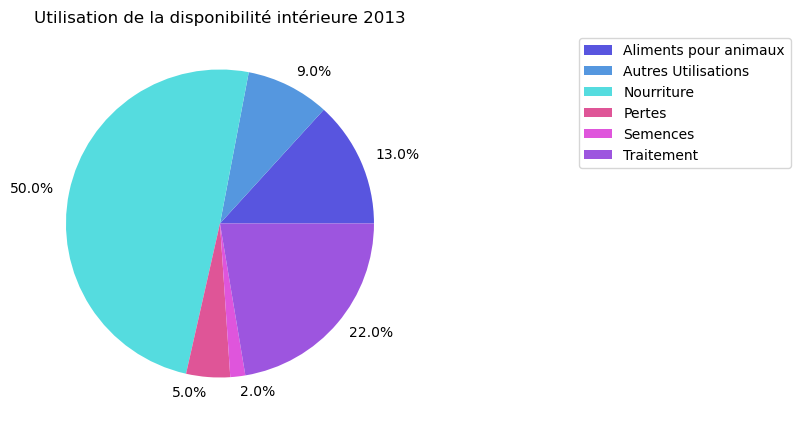

```python
fig = plt.figure(figsize= [5,5])
ax = fig.add_subplot()
ax.pie(proportions_utilisation_dispo_intérieure_topie,
        labels = labels_proportions_pie,
        colors = ['#5855DF','#5597DF','#55DCDF','#DF5597', '#DF55DC','#9D55DF' ],
       )
ax.legend(proportions_utilisation_dispo_intérieure_topie.index, bbox_to_anchor=(2, 1))
ax.set_title("Utilisation de la disponibilité intérieure 2013")
plt.show()
```

```python
#projection sur les colonnes flux pour la réalisation d'un graphique en barres :
proportions_provenance_dispo_intérieure_tobar = proportions_dispo_intérieure[['Production', 'Importations - Quantité','Exportations - Quantité','Variation de stock']]
```

```python
proportions_provenance_dispo_intérieure_tobar
```

```
Production                 1.016315
Importations - Quantité    0.131592
Exportations - Quantité    0.137289
Variation de stock        -0.010600
dtype: float64
```

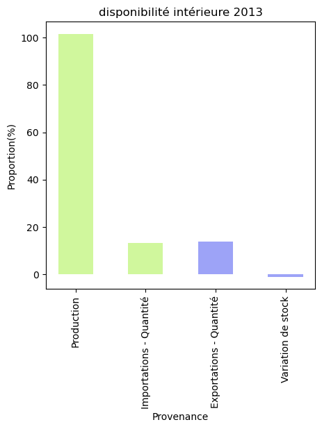

```python
fig = plt.figure(figsize= [5,5])
ax = fig.add_subplot()
bar_positions = range (1,5)
bar_heights =  proportions_provenance_dispo_intérieure_tobar*100
ax.bar(bar_positions,bar_heights, width = 0.5, color=['#D0F79D', '#D0F79D', '#9DA3F7', '#9DA3F7'])
ax.set_title("disponibilité intérieure 2013")
ax.set_xlabel("Provenance")
ax.set_ylabel("Proportion(%)")
tick_positions = range(1,5)
ax.set_xticks(tick_positions)
ax.set_xticklabels(proportions_provenance_dispo_intérieure_tobar.index, rotation = 90)
plt.show()
```

## 5 Utilisation des céréales

création de la liste des céréales à partir du fichier FAO, correction de la liste // aux valeurs du fichier disponibilité alimentaire, utilisation du df disponibilité intérieure, restriction sur les produits de type cereale avec la fonction isin(), projection sur les colonnes qui précisent les utilisations/moyens d’acquisition de la disponibilité alimentaire, création et application d'une fonction calcul des proportions, création d'un pie chart (création d'un vecteur valeurs, création d'une liste de labels)

```python
#import du fichier issu du site de la FAO :
cereales = pd.read_csv('FAOSTAT_data_6-22-2021.csv')
```

```python
cereales['Produit'].unique()
```

```
array(['Blé et produits', 'Riz (Eq Blanchi)', 'Orge et produits',
       'Maïs et produits', 'Millet et produits', 'Céréales, Autres',
       'Seigle et produits', 'Avoine', 'Sorgho et produits'], dtype=object)
```

```python
#les intitulés des céréales ne correspondent pas sur toutes les valeurs ( ok pour : 'Riz (Eq Blanchi)'', 'Céréales, Autres', 'Avoine' )
#recherche des termes exacts dans la colonne Produit du df disponibilité alimentaire
#dispo_alimentaire[dispo_alimentaire["Produit"].str.contains('riz', case=False)]["Produit"].unique()
#dispo_alimentaire[dispo_alimentaire["Produit"].str.contains('blé', case=False)]["Produit"].unique()
#etc...
```

```python
cereales_corrigées=['Blé', 'Riz (Eq Blanchi)', 'Orge', 'Maïs', 'Seigle', 'Avoine','Millet', 'Sorgho', 'Céréales, Autres']
```

```python
#restriction sur les valeurs produit = céréale :
dispo_alimentaire_cereales = dispo_alimentaire[dispo_alimentaire["Produit"].isin(cereales_corrigées)]
```

```python
dispo_alimentaire_cereales.head()
```

|  | Zone | Produit | Origine | Aliments pour animaux | Autres Utilisations | Disponibilité alimentaire (Kcal/personne/jour) | Disponibilité alimentaire en quantité (kg/personne/an) | Disponibilité de matière grasse en quantité (g/personne/jour) | Disponibilité de protéines en quantité (g/personne/jour) | Disponibilité intérieure | Exportations - Quantité | Importations - Quantité | Nourriture | Pertes | Production | Semences | Traitement | Variation de stock |
| --- | --- | --- | --- | --- | --- | --- | --- | --- | --- | --- | --- | --- | --- | --- | --- | --- | --- | --- |
| 7 | Afghanistan | Blé | vegetale | NaN | NaN | 1369.0 | 160.23 | 4.69 | 36.91 | 5992.0 | NaN | 1173.0 | 4895.0 | 775.0 | 5169.0 | 322.0 | NaN | -350.0 |
| 12 | Afghanistan | Céréales, Autres | vegetale | NaN | NaN | 0.0 | 0.00 | 0.00 | 0.00 | 0.0 | NaN | 0.0 | 0.0 | NaN | NaN | NaN | NaN | NaN |
| 32 | Afghanistan | Maïs | vegetale | 200.0 | NaN | 21.0 | 2.50 | 0.30 | 0.56 | 313.0 | 0.0 | 1.0 | 76.0 | 31.0 | 312.0 | 5.0 | NaN | NaN |
| 34 | Afghanistan | Millet | vegetale | NaN | NaN | 3.0 | 0.40 | 0.02 | 0.08 | 13.0 | NaN | NaN | 12.0 | 1.0 | 13.0 | 0.0 | NaN | NaN |
| 40 | Afghanistan | Orge | vegetale | 360.0 | NaN | 26.0 | 2.92 | 0.24 | 0.79 | 524.0 | NaN | 10.0 | 89.0 | 52.0 | 514.0 | 22.0 | NaN | 0.0 |

### 5.1 Proportions nourriture et alimentation animaux uniquement

```python
sum_cereales_animaux = dispo_alimentaire_cereales["Aliments pour animaux"].sum()
sum_cereales_nourriture = dispo_alimentaire_cereales["Nourriture"].sum()
total_cereale_nourriture_ou_animaux = sum_cereales_animaux + sum_cereales_nourriture
total_cereale_nourriture_ou_animaux
```

```
1902545.0
```

```python
proportion_cereales_animaux = sum_cereales_animaux/total_cereale_nourriture_ou_animaux
print(f'la proportion d\'utilisation des céréales pour les animaux : {round(proportion_cereales_animaux,2)}')
proportion_cereales_nourriture = sum_cereales_nourriture/total_cereale_nourriture_ou_animaux
print(f'la proportion d\'utilisation des céréales pour l\'alimentation humaine est de : {round(proportion_cereales_nourriture,2)}')
```

```
la proportion d'utilisation des céréales pour les animaux : 0.46
la proportion d'utilisation des céréales pour l'alimentation humaine est de : 0.54
```

```python
#création des labels pour le pie chart :
labels_cereales_animaux_nourriture = []
for element in [proportion_cereales_animaux, proportion_cereales_nourriture] :
    element = np.round(element,2) * 100
    element = f'{element}%'
    labels_cereales_animaux_nourriture.append(element)

print (labels_cereales_animaux_nourriture)
```

```
['46.0%', '54.0%']
```

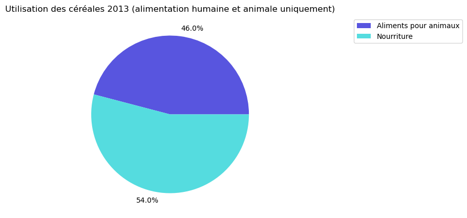

```python
fig = plt.figure(figsize= (5,5))
ax = fig.add_subplot()
ax.pie([proportion_cereales_animaux, proportion_cereales_nourriture],
        labels = labels_cereales_animaux_nourriture,
        colors = ['#5855DF','#55DCDF'],
       )
ax.legend(["Aliments pour animaux", "Nourriture"], bbox_to_anchor=(2, 1))
ax.set_title("Utilisation des céréales 2013 (alimentation humaine et animale uniquement)")
plt.show()
```

### 5.2 Proportions toutes utilisations confondues

```python
dispo_alimentaire_cereales.head()
```

|  | Zone | Produit | Origine | Aliments pour animaux | Autres Utilisations | Disponibilité alimentaire (Kcal/personne/jour) | Disponibilité alimentaire en quantité (kg/personne/an) | Disponibilité de matière grasse en quantité (g/personne/jour) | Disponibilité de protéines en quantité (g/personne/jour) | Disponibilité intérieure | Exportations - Quantité | Importations - Quantité | Nourriture | Pertes | Production | Semences | Traitement | Variation de stock |
| --- | --- | --- | --- | --- | --- | --- | --- | --- | --- | --- | --- | --- | --- | --- | --- | --- | --- | --- |
| 7 | Afghanistan | Blé | vegetale | NaN | NaN | 1369.0 | 160.23 | 4.69 | 36.91 | 5992.0 | NaN | 1173.0 | 4895.0 | 775.0 | 5169.0 | 322.0 | NaN | -350.0 |
| 12 | Afghanistan | Céréales, Autres | vegetale | NaN | NaN | 0.0 | 0.00 | 0.00 | 0.00 | 0.0 | NaN | 0.0 | 0.0 | NaN | NaN | NaN | NaN | NaN |
| 32 | Afghanistan | Maïs | vegetale | 200.0 | NaN | 21.0 | 2.50 | 0.30 | 0.56 | 313.0 | 0.0 | 1.0 | 76.0 | 31.0 | 312.0 | 5.0 | NaN | NaN |
| 34 | Afghanistan | Millet | vegetale | NaN | NaN | 3.0 | 0.40 | 0.02 | 0.08 | 13.0 | NaN | NaN | 12.0 | 1.0 | 13.0 | 0.0 | NaN | NaN |
| 40 | Afghanistan | Orge | vegetale | 360.0 | NaN | 26.0 | 2.92 | 0.24 | 0.79 | 524.0 | NaN | 10.0 | 89.0 | 52.0 | 514.0 | 22.0 | NaN | 0.0 |

```python
#projection sur les colonnes utilisation :
utilisation_cereales= dispo_alimentaire_cereales[['Disponibilité intérieure', 'Aliments pour animaux', 'Autres Utilisations','Nourriture', 'Pertes',
       'Semences', 'Traitement']]
```

```python
utilisation_cereales
```

|  | Disponibilité intérieure | Aliments pour animaux | Autres Utilisations | Nourriture | Pertes | Semences | Traitement |
| --- | --- | --- | --- | --- | --- | --- | --- |
| 7 | 5992.0 | NaN | NaN | 4895.0 | 775.0 | 322.0 | NaN |
| 12 | 0.0 | NaN | NaN | 0.0 | NaN | NaN | NaN |
| 32 | 313.0 | 200.0 | NaN | 76.0 | 31.0 | 5.0 | NaN |
| 34 | 13.0 | NaN | NaN | 12.0 | 1.0 | 0.0 | NaN |
| 40 | 524.0 | 360.0 | NaN | 89.0 | 52.0 | 22.0 | NaN |
| ... | ... | ... | ... | ... | ... | ... | ... |
| 15545 | 0.0 | NaN | NaN | 0.0 | 0.0 | NaN | NaN |
| 15568 | 0.0 | NaN | NaN | 0.0 | NaN | NaN | NaN |
| 15575 | 1.0 | NaN | NaN | 0.0 | NaN | NaN | 1.0 |
| 15591 | 49.0 | 0.0 | 12.0 | 36.0 | 1.0 | 0.0 | NaN |
| 15593 | 0.0 | 0.0 | NaN | NaN | NaN | NaN | NaN |

1497 rows × 7 columns

```python
#création d'une fonction pour le calcul des proportions céréales :
def proportion_utilisation_cereales (column) :
    return column.sum()/utilisation_cereales['Disponibilité intérieure'].sum()
```

```python
#application de la fontion avec la méthode apply :
proportions_utilisation_cereales = utilisation_cereales.apply(proportion_utilisation_cereales)
proportions_utilisation_cereales
```

```
Disponibilité intérieure    1.000000
Aliments pour animaux       0.362915
Autres Utilisations         0.097543
Nourriture                  0.427507
Pertes                      0.044504
Semences                    0.028474
Traitement                  0.039297
dtype: float64
```

```python
#projection sur les colonnes pour la création du pie chart :
proportions_utilisation_cereales_topie = proportions_utilisation_cereales[['Aliments pour animaux', 'Autres Utilisations','Nourriture','Pertes',
       'Semences', 'Traitement']]
```

```python
proportions_utilisation_cereales_topie.sum()
```

```
1.0002409639555312
```

```python
#création des labels avec une boucle for :
labels_proportions_cereales_pie = []
for element in proportions_utilisation_cereales_topie.values :
    element = np.round(element,2) * 100
    element = f'{element}%'
    labels_proportions_cereales_pie.append(element)

print (labels_proportions_cereales_pie)
```

```
['36.0%', '10.0%', '43.0%', '4.0%', '3.0%', '4.0%']
```

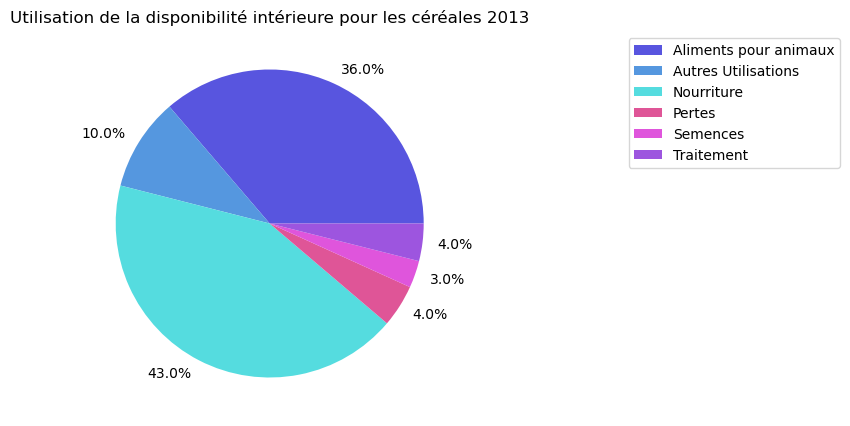

```python
fig = plt.figure(figsize= [5,5])
ax = fig.add_subplot()
ax.pie(proportions_utilisation_cereales_topie,
        labels = labels_proportions_cereales_pie,
        colors = ['#5855DF','#5597DF','#55DCDF','#DF5597', '#DF55DC','#9D55DF' ],
       )
ax.legend(proportions_utilisation_cereales_topie.index, bbox_to_anchor=(2, 1))
ax.set_title("Utilisation de la disponibilité intérieure pour les céréales 2013")
plt.show()
```

## 6 Utilisation du manioc par la Thaïlande

### 6.1 Proportion de thaïlandais en état de sous-nutrition

utilisation des df insécurité alimentaire et population, application d'un masque à conditions multiples (2013 et Thaïlande), sommes, proportion

```python
insecurite_alimentaire_2013_thailande = insecurite_alimentaire[(insecurite_alimentaire["Année"] == 2013)&(insecurite_alimentaire["Zone"] == "Thaïlande")]["Valeur"].values
nbr_thailandais_sousnutrition_2013 = int(insecurite_alimentaire_2013_thailande)
print(f'le nombre de thaïlandais en état de sous-nutrition en 2013 est de : {nbr_thailandais_sousnutrition_2013}')
```

```
le nombre de thaïlandais en état de sous-nutrition en 2013 est de : 6200000
```

```python
population_2013_thailande = population[(population["Zone"] == "Thaïlande")&(population["Année"] == 2013)]["Valeur"].values
nbr_thailandais_2013 = int(population_2013_thailande)
print(f'la population thaïlandaise en 2013 s\'élève à : {nbr_thailandais_2013} habitants')
```

```
la population thaïlandaise en 2013 s'élève à : 68144518 habitants
```

```python
proportion_thailandais_sousnutrition_2013 = round(nbr_thailandais_sousnutrition_2013/nbr_thailandais_2013,2)*100
print(f'la proportion de thaïlandais en état de sous-nutrition en 2013 s\'élève à : {proportion_thailandais_sousnutrition_2013} % de la population')
```

```
la proportion de thaïlandais en état de sous-nutrition en 2013 s'élève à : 9.0 % de la population
```

### 6.2 Utilisation de la production de manioc en 2013 en Thaïlande

utilisation du df disponibilité alimentaire, masque sur les valeurs Thailande et manioc, calcul des proportions, cration d'un vecteur valeur(bar height), création d'un digramme en barre.

```python
#création d'un masque sur les valeurs Thaïlande et manioc :
dispo_alimentaire_manioc_thailande_2013 = dispo_alimentaire[(dispo_alimentaire["Zone"] == "Thaïlande")&(dispo_alimentaire["Produit"].str.contains("manioc",case = False))]
```

```python
dispo_alimentaire_manioc_thailande_2013
```

|  | Zone | Produit | Origine | Aliments pour animaux | Autres Utilisations | Disponibilité alimentaire (Kcal/personne/jour) | Disponibilité alimentaire en quantité (kg/personne/an) | Disponibilité de matière grasse en quantité (g/personne/jour) | Disponibilité de protéines en quantité (g/personne/jour) | Disponibilité intérieure | Exportations - Quantité | Importations - Quantité | Nourriture | Pertes | Production | Semences | Traitement | Variation de stock |
| --- | --- | --- | --- | --- | --- | --- | --- | --- | --- | --- | --- | --- | --- | --- | --- | --- | --- | --- |
| 13809 | Thaïlande | Manioc | vegetale | 1800.0 | 2081.0 | 40.0 | 13.0 | 0.05 | 0.14 | 6264.0 | 25214.0 | 1250.0 | 871.0 | 1511.0 | 30228.0 | NaN | 0.0 | 0.0 |

```python
#projection dur les colonnes flux et calcul des proportions en pourcentage :
utilisation_production_manioc_thailande_2013_topie = dispo_alimentaire_manioc_thailande_2013[["Exportations - Quantité","Importations - Quantité","Disponibilité intérieure","Variation de stock"]]/float(dispo_alimentaire_manioc_thailande_2013["Production"].values)*100
```

```python
utilisation_production_manioc_thailande_2013_topie
```

|  | Exportations - Quantité | Importations - Quantité | Disponibilité intérieure | Variation de stock |
| --- | --- | --- | --- | --- |
| 13809 | 83.41273 | 4.135239 | 20.722509 | 0.0 |

```python
#création d'un series
utilisation_production_manioc_thailande_2013_topie_series = utilisation_production_manioc_thailande_2013_topie.loc[13809,:]
```

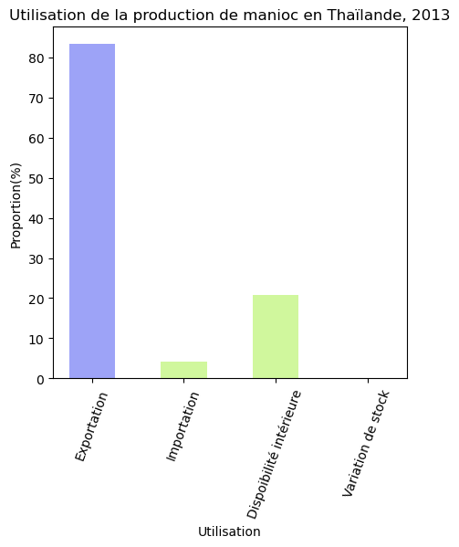

```python
fig = plt.figure(figsize= [5,5])
ax = fig.add_subplot()
bar_positions = range (1,5)
bar_heights =  utilisation_production_manioc_thailande_2013_topie_series
ax.bar(bar_positions,bar_heights, width = 0.5, color=[ '#9DA3F7', '#D0F79D','#D0F79D', '#D0F79D',])
ax.set_title("Utilisation de la production de manioc en Thaïlande, 2013")
ax.set_xlabel("Utilisation")
ax.set_ylabel("Proportion(%)")
tick_positions = range(1,5)
ax.set_xticks(tick_positions)
ax.set_xticklabels(["Exportation", "Importation", "Dispoibilité intérieure", "Variation de stock"], rotation = 70)
plt.show()
```

## 7 Les 10 pays pour lesquels la proportion de personnes sous-alimentées est la plus forte en 2017

Utilisation des df insecurité alimentaire et population, masque sur l'année 2017, left join sur le df insecurité alimentaire, rename sur les colonnes "valeur", création d'une colonne proportion personnes sous alimentées, tri desc des valeurs, création d'une carte choroplèthe avec geopandas.

```python
#masque sur l'année 2017 pour le df insécurité alimentaire :
insecurite_alimentaire_2017 = insecurite_alimentaire[insecurite_alimentaire["Année"] == 2017]
```

```python
#masque sur l'année 2017 pour le df population :
population_2017 = population[population["Année"] == 2017]
population_2017.head()
```

|  | Zone | Année | Valeur |
| --- | --- | --- | --- |
| 4 | Afghanistan | 2017 | 36296113.0 |
| 10 | Afrique du Sud | 2017 | 57009756.0 |
| 16 | Albanie | 2017 | 2884169.0 |
| 22 | Algérie | 2017 | 41389189.0 |
| 28 | Allemagne | 2017 | 82658409.0 |

```python
#fusion des 2 df au moyen d'un left join sur les df insécurité alimentaire :
insecurite_alimentaire_population_2017_merge = pd.merge(insecurite_alimentaire_2017[["Zone","Valeur"]], population_2017[["Zone","Valeur"]], on = "Zone", how = "left")
```

```python
insecurite_alimentaire_population_2017_merge.info()
```

```
<class 'pandas.core.frame.DataFrame'>
Int64Index: 203 entries, 0 to 202
Data columns (total 3 columns):
 #   Column    Non-Null Count  Dtype
---  ------    --------------  -----
 0   Zone      203 non-null    object
 1   Valeur_x  84 non-null     float64
 2   Valeur_y  203 non-null    float64
dtypes: float64(2), object(1)
memory usage: 6.3+ KB
```

```python
#rename colonnes :
insecurite_alimentaire_population_2017_merge.rename(columns={"Valeur_x":"Personnes_sous_alimentées_2017"}, inplace = True)
insecurite_alimentaire_population_2017_merge.rename(columns={"Valeur_y":"Population_2017"}, inplace = True)
```

```python
insecurite_alimentaire_population_2017_merge.head()
```

|  | Zone | Personnes_sous_alimentées_2017 | Population_2017 |
| --- | --- | --- | --- |
| 0 | Afghanistan | 10500000.0 | 36296113.0 |
| 1 | Afrique du Sud | 3100000.0 | 57009756.0 |
| 2 | Albanie | 100000.0 | 2884169.0 |
| 3 | Algérie | 1300000.0 | 41389189.0 |
| 4 | Allemagne | NaN | 82658409.0 |

```python
#création d'une colonne Proportion_personnes_sous_alimentées_2017 :
insecurite_alimentaire_population_2017_merge["Proportion_personnes_sous_alimentées_2017"] = insecurite_alimentaire_population_2017_merge["Personnes_sous_alimentées_2017"]/insecurite_alimentaire_population_2017_merge["Population_2017"]
```

```python
#tri des valeurs :
insecurite_alimentaire_population_2017_sorted = insecurite_alimentaire_population_2017_merge.sort_values(by = ["Proportion_personnes_sous_alimentées_2017"], ascending= False)
```

```python
print ('Les 10 pays ayant les proportions de personnes sous-alimentées en 2017 les plus importantes sont : ')
insecurite_alimentaire_population_2017_sorted.iloc[:10]
```

```
Les 10 pays ayant les proportions de personnes sous-alimentées en 2017 les plus importantes sont :
```

|  | Zone | Personnes_sous_alimentées_2017 | Population_2017 | Proportion_personnes_sous_alimentées_2017 |
| --- | --- | --- | --- | --- |
| 78 | Haïti | 5300000.0 | 10982366.0 | 0.482592 |
| 157 | République populaire démocratique de Corée | 12000000.0 | 25429825.0 | 0.471887 |
| 108 | Madagascar | 10500000.0 | 25570512.0 | 0.410629 |
| 103 | Libéria | 1800000.0 | 4702226.0 | 0.382797 |
| 100 | Lesotho | 800000.0 | 2091534.0 | 0.382494 |
| 183 | Tchad | 5700000.0 | 15016753.0 | 0.379576 |
| 161 | Rwanda | 4200000.0 | 11980961.0 | 0.350556 |
| 121 | Mozambique | 9400000.0 | 28649018.0 | 0.328109 |
| 186 | Timor-Leste | 400000.0 | 1243258.0 | 0.321735 |
| 0 | Afghanistan | 10500000.0 | 36296113.0 | 0.289287 |

```python
import geopandas
```

```python
world = geopandas.read_file(geopandas.datasets.get_path('naturalearth_lowres'))
```

```python
#antarctique enlevée de la carte pour esthétique :
world.drop(index=159, inplace=True)
```

```python
top_ten_sous_alimentation = insecurite_alimentaire_population_2017_sorted.iloc[:10]["Zone"]
top_ten_sous_alimentation.tolist()
```

```
['Haïti',
 'République populaire démocratique de Corée',
 'Madagascar',
 'Libéria',
 'Lesotho',
 'Tchad',
 'Rwanda',
 'Mozambique',
 'Timor-Leste',
 'Afghanistan']
```

```python
#création de la liste des 10 pays en iso A3 :
top_ten_isoA3_sous_alimentation = ['HTI', 'PRK', 'MDG', 'LBR', 'LSO', 'TCD', 'RWA', 'MOZ', 'TLS', 'AFG']
```

```python
world['top_ten_sous_alimentation_2017'] = world['iso_a3'].isin(top_ten_isoA3_sous_alimentation)
```

```python
world[world['top_ten_sous_alimentation_2017'] == True]
```

|  | pop_est | continent | name | iso_a3 | gdp_md_est | geometry | top_ten_sous_alimentation_2017 |
| --- | --- | --- | --- | --- | --- | --- | --- |
| 15 | 12075985 | Africa | Chad | TCD | 30590.0 | POLYGON ((23.83766 19.58047, 23.88689 15.61084... | True |
| 16 | 10646714 | North America | Haiti | HTI | 19340.0 | POLYGON ((-71.71236 19.71446, -71.62487 19.169... | True |
| 24 | 1291358 | Asia | Timor-Leste | TLS | 4975.0 | POLYGON ((124.96868 -8.89279, 125.08625 -8.656... | True |
| 26 | 1958042 | Africa | Lesotho | LSO | 6019.0 | POLYGON ((28.97826 -28.95560, 29.32517 -29.257... | True |
| 63 | 4689021 | Africa | Liberia | LBR | 3881.0 | POLYGON ((-8.43930 7.68604, -8.48545 7.39521, ... | True |
| 72 | 26573706 | Africa | Mozambique | MOZ | 35010.0 | POLYGON ((34.55999 -11.52002, 35.31240 -11.439... | True |
| 78 | 25054161 | Africa | Madagascar | MDG | 36860.0 | POLYGON ((49.54352 -12.46983, 49.80898 -12.895... | True |
| 95 | 25248140 | Asia | North Korea | PRK | 40000.0 | MULTIPOLYGON (((130.78000 42.22001, 130.78000 ... | True |
| 103 | 34124811 | Asia | Afghanistan | AFG | 64080.0 | POLYGON ((66.51861 37.36278, 67.07578 37.35614... | True |
| 169 | 11901484 | Africa | Rwanda | RWA | 21970.0 | POLYGON ((30.41910 -1.13466, 30.81613 -1.69891... | True |

```
Les 10 pays ayant les proportions de personnes sous-alimentées en 2017 les plus importantes sont :
```

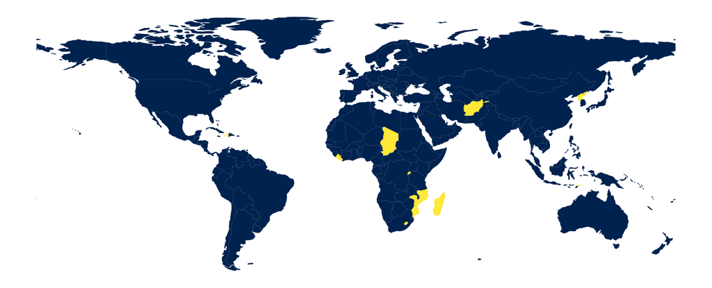

```python
print ('Les 10 pays ayant les proportions de personnes sous-alimentées en 2017 les plus importantes sont : ')
world.plot(column='top_ten_sous_alimentation_2017', cmap='cividis', figsize=(20, 20)).axis('off')
plt.show()
```

## 8 Les 10 Pays ayant le plus bénéficié d’aide depuis 2013

utilisation du df aide alimentaire, méthode groupby, tri des valeurs, création d'un df et rename colonne, création carte choroplèthe.

```python
#méthode groupby, tri des valeurs, création d'un df et rename colonne
aide_alimentaire_par_pays = aide_alimentaire.groupby(by = "Zone")["Valeur"].sum()
aide_alimentaire_par_pays_sorted = aide_alimentaire_par_pays.sort_values(ascending= False)
print ('Les 10 ayant le plus bénéficié d\'aide alimentaire depuis 2013 sont : ')
df_aide_alimentaire_par_pays_sorted = pd.DataFrame(data = aide_alimentaire_par_pays_sorted.iloc[:10]).rename(columns={"Valeur":"Aide alimentaires en tonne"})
df_aide_alimentaire_par_pays_sorted
```

```
Les 10 ayant le plus bénéficié d'aide alimentaire depuis 2013 sont :
```

| Zone | Aide alimentaires en tonne |
| --- | --- |
| République arabe syrienne | 1858943 |
| Éthiopie | 1381294 |
| Yémen | 1206484 |
| Soudan du Sud | 695248 |
| Soudan | 669784 |
| Kenya | 552836 |
| Bangladesh | 348188 |
| Somalie | 292678 |
| République démocratique du Congo | 288502 |
| Niger | 276344 |

```python
#création de la liste des 10 pays en iso A3 :
top_ten_isoA3_aide= ['SYR', 'ETH', 'YEM', 'SSD', 'SDN', 'KEN', 'BGD', 'SOM', 'COD', 'NER']
```

```python
world['top_ten_aide_2013_2016'] = world['iso_a3'].isin(top_ten_isoA3_aide)
```

```
Les 10 ayant le plus bénéficié d'aide alimentaire depuis 2013 sont :
```

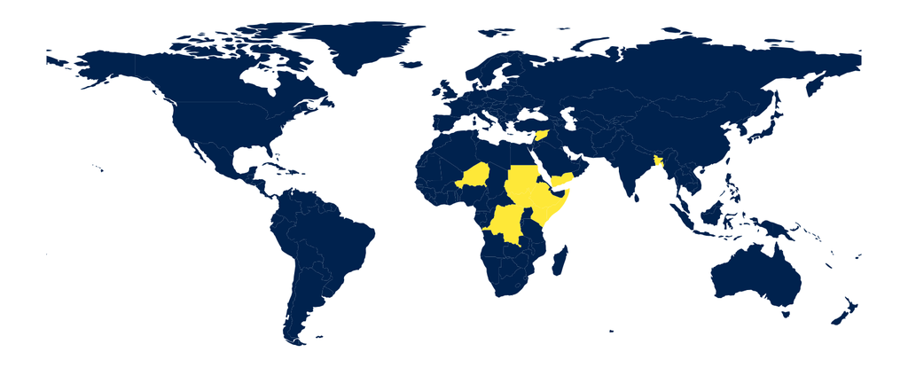

```python
print ('Les 10 ayant le plus bénéficié d\'aide alimentaire depuis 2013 sont : ')
world.plot(column='top_ten_aide_2013_2016', cmap='cividis', figsize=(20, 20)).axis('off')
plt.show()
```

## 9 Les 10 pays ayant le plus/le moins de disponibilité/habitant

utilisation du df disponibilité alimentaire, utilisation de la table pivot calories_2013_perperson_perday_perzone_pivot, tri des valeurs asc puis desc, création de la carte choroplèthe

```python
#utilisation de la table pivot calories_2013_perperson_perday_perzone_pivot et tri des valeurs croissant :
disponibilité_alimentaire_par_habitant_classement_asc = calories_2013_perperson_perday_perzone_pivot.sort_values(by = "Disponibilité alimentaire (Kcal/personne/jour)", ascending=True)
```

```python
print ('Les 10 ayant le moins de disponibilité alimentaire par habitant en 2013 sont : ')
disponibilité_alimentaire_par_habitant_classement_asc.iloc[:10]
```

```
Les 10 ayant le moins de disponibilité alimentaire par habitant en 2013 sont :
```

| Zone | Disponibilité alimentaire (Kcal/personne/jour) |
| --- | --- |
| République centrafricaine | 1879.0 |
| Zambie | 1924.0 |
| Madagascar | 2056.0 |
| Afghanistan | 2087.0 |
| Haïti | 2089.0 |
| République populaire démocratique de Corée | 2093.0 |
| Tchad | 2109.0 |
| Zimbabwe | 2113.0 |
| Ouganda | 2126.0 |
| Timor-Leste | 2129.0 |

```python
#création de la liste des 10 pays en iso A3 :
top_ten_isoA3_dispo_alimentaire_asc= ['CAF', 'ZMB', 'MDG', 'AFG','HTI', 'PRK', 'TCD', 'ZWE', 'UGA', 'TLS' ]
```

```python
world['top_ten_dispo_alimentaire_asc_2013'] = world['iso_a3'].isin(top_ten_isoA3_dispo_alimentaire_asc)
```

```
Les 10 ayant le moins de disponibilité alimentaire par habitant en 2013 sont :
```

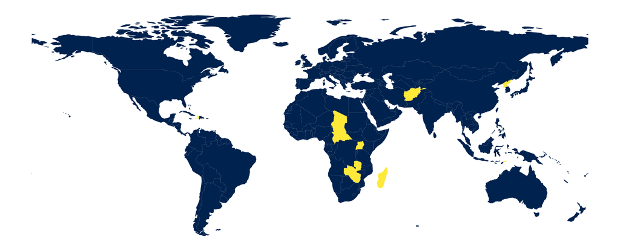

```python
print ('Les 10 ayant le moins de disponibilité alimentaire par habitant en 2013 sont : ')
world.plot(column='top_ten_dispo_alimentaire_asc_2013', cmap='cividis', figsize=(20, 20)).axis('off')
plt.show()
```

```python
#utilisation de la table pivot calories_2013_perperson_perday_perzone_pivot et tri des valeurs décroissant :
disponibilité_alimentaire_par_habitant_classement_desc = calories_2013_perperson_perday_perzone_pivot.sort_values(by = "Disponibilité alimentaire (Kcal/personne/jour)", ascending=False)
```

```python
print ('Les 10 ayant le plus de disponibilité alimentaire par habitant en 2013 sont : ')
disponibilité_alimentaire_par_habitant_classement_desc.iloc[:10]
```

```
Les 10 ayant le plus de disponibilité alimentaire par habitant en 2013 sont :
```

| Zone | Disponibilité alimentaire (Kcal/personne/jour) |
| --- | --- |
| Autriche | 3770.0 |
| Belgique | 3737.0 |
| Turquie | 3708.0 |
| États-Unis d'Amérique | 3682.0 |
| Israël | 3610.0 |
| Irlande | 3602.0 |
| Italie | 3578.0 |
| Luxembourg | 3540.0 |
| Égypte | 3518.0 |
| Allemagne | 3503.0 |

```python
top_ten_dispo_alimentaire_desc = disponibilité_alimentaire_par_habitant_classement_desc.iloc[:10].index
top_ten_dispo_alimentaire_desc.tolist()
```

```
['Autriche',
 'Belgique',
 'Turquie',
 "États-Unis d'Amérique",
 'Israël',
 'Irlande',
 'Italie',
 'Luxembourg',
 'Égypte',
 'Allemagne']
```

```python
#création de la liste des 10 pays en iso A3 :
top_ten_isoA3_dispo_alimentaire_desc= ['AUT', 'BEL', 'TUR', 'USA','ISR', 'IRL', 'ITA', 'LUX', 'EGY', 'DEU' ]
```

```python
world['top_ten_dispo_alimentaire_desc_2013'] = world['iso_a3'].isin(top_ten_isoA3_dispo_alimentaire_desc)
```

```
Les 10 ayant le plus de disponibilité alimentaire par habitant en 2013 sont :
```

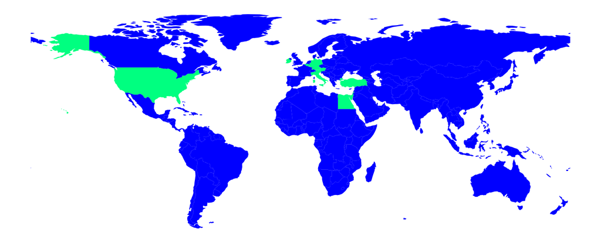

```python
print ('Les 10 ayant le plus de disponibilité alimentaire par habitant en 2013 sont : ')
world.plot(column='top_ten_dispo_alimentaire_desc_2013', cmap='winter', figsize=(20, 20)).axis('off')
plt.show()
```

# III Analyses complémentaires

## Aide alimentaire en fonction du nombre de personnes en état de sous nutrition, 2013

utilisation des df insecurité alimentaire et aide alimentaire, méthode groupby sur le df aide alimentaire, élimination des valeurs nulles pour le df indecurité alimentaire (dropna()) ou = 0 pour le df aide alimentaire (masque), merge sur les deux df, création d'une scatterplot (50 valeurs)

```python
insecurite_alimentaire_2013 = insecurite_alimentaire[insecurite_alimentaire["Année"] == 2013].sort_values(by = "Valeur", ascending = False).dropna()
insecurite_alimentaire_2013 = insecurite_alimentaire_2013.rename(columns={"Valeur":"Nbr de personnes sous-alimentées"})
```

```python
aide_alimentaire_2013 = aide_alimentaire[aide_alimentaire["Année"] == 2013].groupby("Zone")["Valeur"].sum().sort_values(ascending = False)
```

```python
aide_alimentaire_2013 = pd.DataFrame(data = aide_alimentaire_2013).reset_index()
```

```python
aide_alimentaire_2013 = aide_alimentaire_2013[aide_alimentaire_2013["Valeur"] >0]
aide_alimentaire_2013  = aide_alimentaire_2013.rename(columns={'Valeur' : 'Aide alimentaire (tonnes)'})
```

```python
aide_alimentaire_nbr_personnes_sous_alimentées_2013 = pd.merge(insecurite_alimentaire_2013, aide_alimentaire_2013, on = "Zone", how = 'inner')
aide_alimentaire_nbr_personnes_sous_alimentées_2013.drop(columns = "Année")
```

|  | Zone | Nbr de personnes sous-alimentées | Aide alimentaire (tonnes) |
| --- | --- | --- | --- |
| 0 | Pakistan | 31100000.0 | 101364 |
| 1 | Éthiopie | 26200000.0 | 591404 |
| 2 | Bangladesh | 21700000.0 | 131018 |
| 3 | Philippines | 14500000.0 | 62164 |
| 4 | République-Unie de Tanzanie | 13500000.0 | 43116 |
| 5 | République populaire démocratique de Corée | 10300000.0 | 71324 |
| 6 | Kenya | 10100000.0 | 220966 |
| 7 | Afghanistan | 8600000.0 | 128238 |
| 8 | Madagascar | 7600000.0 | 48382 |
| 9 | Angola | 7600000.0 | 5000 |
| 10 | Iraq | 7300000.0 | 666 |
| 11 | Myanmar | 6700000.0 | 6248 |
| 12 | Soudan | 5900000.0 | 330230 |
| 13 | Mozambique | 5900000.0 | 37956 |
| 14 | Haïti | 5100000.0 | 61214 |
| 15 | Tchad | 4900000.0 | 93930 |
| 16 | Côte d'Ivoire | 4800000.0 | 22582 |
| 17 | Égypte | 4400000.0 | 1122 |
| 18 | Colombie | 3900000.0 | 11442 |
| 19 | Iran (République islamique d') | 3600000.0 | 2138 |
| 20 | Burkina Faso | 3100000.0 | 18620 |
| 21 | Guatemala | 2900000.0 | 52626 |
| 22 | Rwanda | 2800000.0 | 8932 |
| 23 | Malawi | 2700000.0 | 53446 |
| 24 | Équateur | 2300000.0 | 1362 |
| 25 | Sierra Leone | 2200000.0 | 17882 |
| 26 | Cambodge | 2100000.0 | 10974 |
| 27 | Ghana | 1900000.0 | 4956 |
| 28 | Sri Lanka | 1800000.0 | 7652 |
| 29 | Népal | 1800000.0 | 12396 |
| 30 | Honduras | 1700000.0 | 27136 |
| 31 | Togo | 1500000.0 | 24804 |
| 32 | Cameroun | 1500000.0 | 4906 |
| 33 | Libéria | 1500000.0 | 17184 |
| 34 | Sénégal | 1400000.0 | 31862 |
| 35 | Congo | 1400000.0 | 8034 |
| 36 | Algérie | 1300000.0 | 35234 |
| 37 | Mali | 1100000.0 | 80486 |
| 38 | Nicaragua | 1100000.0 | 31052 |
| 39 | République dominicaine | 900000.0 | 49024 |
| 40 | Jordanie | 800000.0 | 9472 |
| 41 | Bénin | 800000.0 | 17622 |
| 42 | Liban | 700000.0 | 4654 |
| 43 | El Salvador | 700000.0 | 2010 |
| 44 | Kirghizistan | 400000.0 | 2038 |
| 45 | Timor-Leste | 400000.0 | 116 |
| 46 | Lesotho | 300000.0 | 2966 |
| 47 | Mauritanie | 300000.0 | 25576 |
| 48 | Gambie | 200000.0 | 10108 |
| 49 | Géorgie | 200000.0 | 34 |

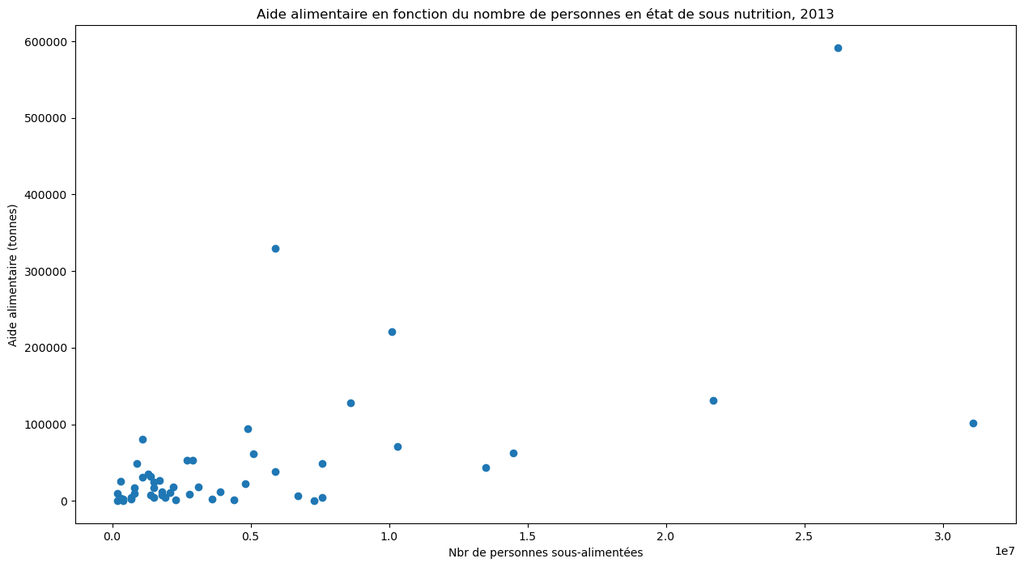

```python
fig = plt.figure(figsize = (15,8))
ax = fig.add_subplot()
ax.scatter(aide_alimentaire_nbr_personnes_sous_alimentées_2013["Nbr de personnes sous-alimentées"], aide_alimentaire_nbr_personnes_sous_alimentées_2013["Aide alimentaire (tonnes)"])
ax.set_xlabel("Nbr de personnes sous-alimentées")
ax.set_ylabel("Aide alimentaire (tonnes)")
ax.set_title("Aide alimentaire en fonction du nombre de personnes en état de sous nutrition, 2013")
plt.show()
```

## Aide alimentaire en fonction du nombre de personnes en état de sous nutrition, 2015

idem 2013 sur valeurs 2015 (40 valeurs)

```python
insecurite_alimentaire_2015 = insecurite_alimentaire[insecurite_alimentaire["Année"] == 2015].sort_values(by = "Valeur", ascending = False).dropna()
insecurite_alimentaire_2015 = insecurite_alimentaire_2015.rename(columns={"Valeur":"Nbr de personnes sous-alimentées"})
```

```python
aide_alimentaire_2015 = aide_alimentaire[aide_alimentaire["Année"] == 2015].groupby("Zone")["Valeur"].sum().sort_values(ascending = False)
```

```python
aide_alimentaire_2015 = pd.DataFrame(data = aide_alimentaire_2015).reset_index()
```

```python
aide_alimentaire_2015 = aide_alimentaire_2015[aide_alimentaire_2015["Valeur"] >0]
aide_alimentaire_2015  = aide_alimentaire_2015.rename(columns={'Valeur' : 'Aide alimentaire (tonnes)'})
```

```python
aide_alimentaire_nbr_personnes_sous_alimentées_2015 = pd.merge(insecurite_alimentaire_2015, aide_alimentaire_2015, on = "Zone", how = 'inner')
aide_alimentaire_nbr_personnes_sous_alimentées_2015.drop(columns = "Année")
```

|  | Zone | Nbr de personnes sous-alimentées | Aide alimentaire (tonnes) |
| --- | --- | --- | --- |
| 0 | Pakistan | 25400000.0 | 19440 |
| 1 | Bangladesh | 23300000.0 | 22542 |
| 2 | Éthiopie | 21700000.0 | 203266 |
| 3 | Philippines | 16500000.0 | 4134 |
| 4 | République-Unie de Tanzanie | 12800000.0 | 52300 |
| 5 | République populaire démocratique de Corée | 11200000.0 | 70506 |
| 6 | Kenya | 10700000.0 | 114452 |
| 7 | Madagascar | 9700000.0 | 26362 |
| 8 | Mozambique | 8400000.0 | 3238 |
| 9 | Iraq | 8400000.0 | 2002 |
| 10 | Myanmar | 7300000.0 | 7154 |
| 11 | Haïti | 5100000.0 | 9666 |
| 12 | Tchad | 5000000.0 | 73678 |
| 13 | Côte d'Ivoire | 4600000.0 | 12648 |
| 14 | Soudan | 4400000.0 | 17650 |
| 15 | Iran (République islamique d') | 3900000.0 | 492 |
| 16 | Burkina Faso | 3200000.0 | 23182 |
| 17 | Colombie | 3100000.0 | 6642 |
| 18 | Malawi | 2900000.0 | 11406 |
| 19 | Guatemala | 2800000.0 | 21046 |
| 20 | Cambodge | 2400000.0 | 2734 |
| 21 | Ghana | 2100000.0 | 2554 |
| 22 | Sierra Leone | 2000000.0 | 904 |
| 23 | Sri Lanka | 1800000.0 | 3524 |
| 24 | Népal | 1700000.0 | 12986 |
| 25 | Sénégal | 1700000.0 | 23900 |
| 26 | Cameroun | 1600000.0 | 32310 |
| 27 | Honduras | 1400000.0 | 12506 |
| 28 | Algérie | 1300000.0 | 17424 |
| 29 | Nicaragua | 1200000.0 | 48432 |
| 30 | Congo | 1200000.0 | 6000 |
| 31 | Mali | 900000.0 | 12856 |
| 32 | République dominicaine | 800000.0 | 236 |
| 33 | Lesotho | 800000.0 | 3050 |
| 34 | Bénin | 800000.0 | 3786 |
| 35 | Jordanie | 800000.0 | 6042 |
| 36 | El Salvador | 700000.0 | 1390 |
| 37 | Kirghizistan | 400000.0 | 700 |
| 38 | Mauritanie | 400000.0 | 14700 |
| 39 | Gambie | 200000.0 | 1050 |

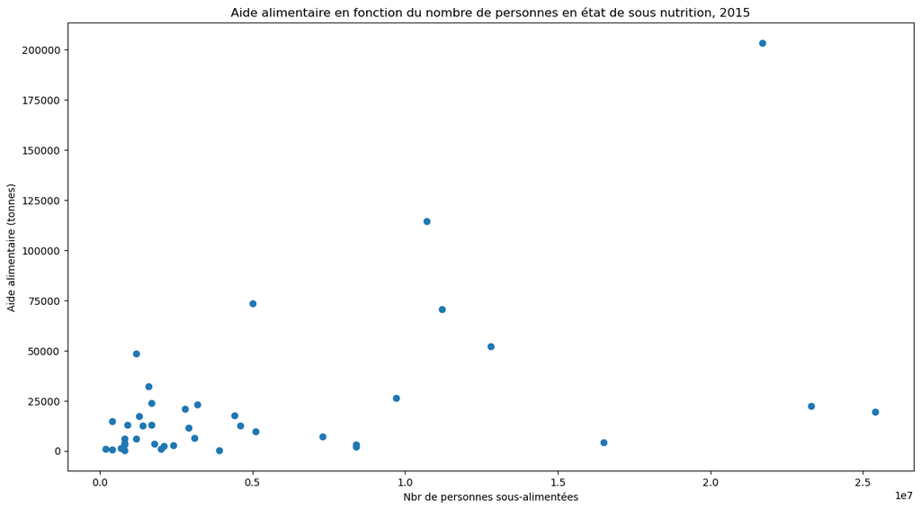

```python
fig = plt.figure(figsize = (15,8))
ax = fig.add_subplot()
ax.scatter(aide_alimentaire_nbr_personnes_sous_alimentées_2015["Nbr de personnes sous-alimentées"], aide_alimentaire_nbr_personnes_sous_alimentées_2015["Aide alimentaire (tonnes)"])
ax.set_xlabel("Nbr de personnes sous-alimentées")
ax.set_ylabel("Aide alimentaire (tonnes)")
ax.set_title("Aide alimentaire en fonction du nombre de personnes en état de sous nutrition, 2015")
plt.show()
```

## Proportion de personnes sous alimentées en fonction de la disponibilité alimentaire par personne et par jour, 2013

utilisation des df population, insecurité alimentaire, disponibilité alimentaire , masque sur les valeurs 2013, merge sur les df créés, création du scatterplot (85 valeurs)

```python
#masque sur la valeur 2013 :
population_2013 = population[population["Année"]==2013]
```

```python
population_2013 = population_2013.loc[:,["Zone", "Valeur"]].rename(columns = {"Valeur" : "Population"})
```

```python
proportion_personnes_sous_alimentées_2013_par_pays = pd.merge(population_2013, insecurite_alimentaire_2013, on = "Zone", how = 'inner')
proportion_personnes_sous_alimentées_2013_par_pays
```

|  | Zone | Population | Année | Nbr de personnes sous-alimentées |
| --- | --- | --- | --- | --- |
| 0 | Afghanistan | 32269589.0 | 2013 | 8600000.0 |
| 1 | Afrique du Sud | 53687121.0 | 2013 | 2200000.0 |
| 2 | Albanie | 2903790.0 | 2013 | 100000.0 |
| 3 | Algérie | 38140133.0 | 2013 | 1300000.0 |
| 4 | Angola | 26015781.0 | 2013 | 7600000.0 |
| ... | ... | ... | ... | ... |
| 80 | Togo | 6954722.0 | 2013 | 1500000.0 |
| 81 | Tunisie | 10952951.0 | 2013 | 300000.0 |
| 82 | Turkménistan | 5366378.0 | 2013 | 300000.0 |
| 83 | Venezuela (République bolivarienne du) | 29781040.0 | 2013 | 1400000.0 |
| 84 | Viet Nam | 90752592.0 | 2013 | 8900000.0 |

85 rows × 4 columns

```python
proportion_personnes_sous_alimentées_2013_par_pays["Proportion de personnes sous alimentées"] = proportion_personnes_sous_alimentées_2013_par_pays["Nbr de personnes sous-alimentées"]/proportion_personnes_sous_alimentées_2013_par_pays["Population"]
```

```python
proportion_personnes_sous_alimentées_2013_par_pays = proportion_personnes_sous_alimentées_2013_par_pays.dropna()
```

```python
 calories_2013_perperson_perday_perzone = calories_2013_perperson_perday_perzone_pivot.reset_index()
```

```python
proportion_personnes_sous_alimentées_vs_dispo_alimentaire_2013= pd.merge(proportion_personnes_sous_alimentées_2013_par_pays, calories_2013_perperson_perday_perzone, on = "Zone", how = 'inner')
```

```python
proportion_personnes_sous_alimentées_vs_dispo_alimentaire_2013
```

|  | Zone | Population | Année | Nbr de personnes sous-alimentées | Proportion de personnes sous alimentées | Disponibilité alimentaire (Kcal/personne/jour) |
| --- | --- | --- | --- | --- | --- | --- |
| 0 | Afghanistan | 32269589.0 | 2013 | 8600000.0 | 0.266505 | 2087.0 |
| 1 | Afrique du Sud | 53687121.0 | 2013 | 2200000.0 | 0.040978 | 3020.0 |
| 2 | Albanie | 2903790.0 | 2013 | 100000.0 | 0.034438 | 3188.0 |
| 3 | Algérie | 38140133.0 | 2013 | 1300000.0 | 0.034085 | 3293.0 |
| 4 | Angola | 26015781.0 | 2013 | 7600000.0 | 0.292130 | 2474.0 |
| ... | ... | ... | ... | ... | ... | ... |
| 80 | Togo | 6954722.0 | 2013 | 1500000.0 | 0.215681 | 2448.0 |
| 81 | Tunisie | 10952951.0 | 2013 | 300000.0 | 0.027390 | 3349.0 |
| 82 | Turkménistan | 5366378.0 | 2013 | 300000.0 | 0.055904 | 2836.0 |
| 83 | Venezuela (République bolivarienne du) | 29781040.0 | 2013 | 1400000.0 | 0.047010 | 2633.0 |
| 84 | Viet Nam | 90752592.0 | 2013 | 8900000.0 | 0.098069 | 2744.0 |

85 rows × 6 columns

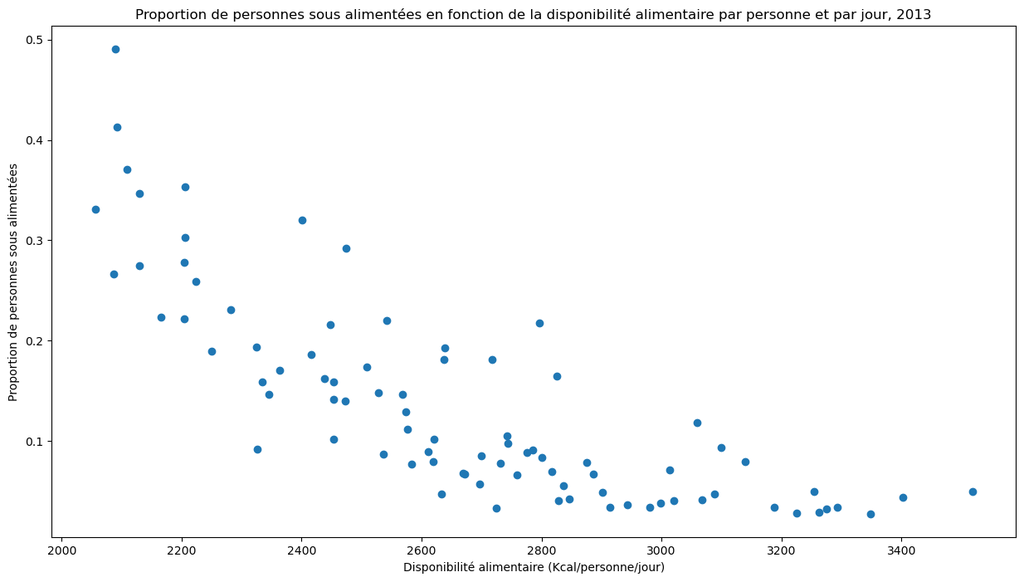

```python
fig = plt.figure(figsize = (15,8))
ax = fig.add_subplot()
ax.scatter(proportion_personnes_sous_alimentées_vs_dispo_alimentaire_2013["Disponibilité alimentaire (Kcal/personne/jour)"], proportion_personnes_sous_alimentées_vs_dispo_alimentaire_2013["Proportion de personnes sous alimentées"])
ax.set_xlabel("Disponibilité alimentaire (Kcal/personne/jour)")
ax.set_ylabel("Proportion de personnes sous alimentées")
ax.set_title("Proportion de personnes sous alimentées en fonction de la disponibilité alimentaire par personne et par jour, 2013")
plt.show()
```

## Pays pour lesquels la proportion de personnes sous alimentées est supérieure à 10% malgrés une disponibilité alimentaire de plus de 2400 kcal par personne et par jour, 2013

création d'un masque avec conditions multiples sur le df proportion_personnes_sous_alimentées_vs_dispo_alimentaire_2013,tri desc sur la proportion de personnes sous alimentées, création d'une liste des pays isoA3 par boucle for en utilisant le fichier csv sql-pays.csv, création d'une carte choroplèthe.

```python
sous_alimentation_vs_dispo_alimentaire_2013 = proportion_personnes_sous_alimentées_vs_dispo_alimentaire_2013[(proportion_personnes_sous_alimentées_vs_dispo_alimentaire_2013["Proportion de personnes sous alimentées"]>=0.10) & (proportion_personnes_sous_alimentées_vs_dispo_alimentaire_2013["Disponibilité alimentaire (Kcal/personne/jour)"]>=2400)].sort_values(by = ["Proportion de personnes sous alimentées"], ascending= False)
sous_alimentation_vs_dispo_alimentaire_2013
```

|  | Zone | Population | Année | Nbr de personnes sous-alimentées | Proportion de personnes sous alimentées | Disponibilité alimentaire (Kcal/personne/jour) |
| --- | --- | --- | --- | --- | --- | --- |
| 73 | Sierra Leone | 6.863981e+06 | 2013 | 2200000.0 | 0.320514 | 2401.0 |
| 4 | Angola | 2.601578e+07 | 2013 | 7600000.0 | 0.292130 | 2474.0 |
| 37 | Iraq | 3.315705e+07 | 2013 | 7300000.0 | 0.220164 | 2542.0 |
| 20 | Côte d'Ivoire | 2.208750e+07 | 2013 | 4800000.0 | 0.217317 | 2797.0 |
| 80 | Togo | 6.954722e+06 | 2013 | 1500000.0 | 0.215681 | 2448.0 |
| 33 | Honduras | 8.798521e+06 | 2013 | 1700000.0 | 0.193214 | 2639.0 |
| 31 | Guatemala | 1.559582e+07 | 2013 | 2900000.0 | 0.185947 | 2416.0 |
| 12 | Burkina Faso | 1.707278e+07 | 2013 | 3100000.0 | 0.181576 | 2717.0 |
| 58 | Nicaragua | 6.062457e+06 | 2013 | 1100000.0 | 0.181445 | 2638.0 |
| 53 | Mongolie | 2.881791e+06 | 2013 | 500000.0 | 0.173503 | 2509.0 |
| 27 | Gabon | 1.817071e+06 | 2013 | 300000.0 | 0.165101 | 2826.0 |
| 62 | Pakistan | 1.912608e+08 | 2013 | 31100000.0 | 0.162605 | 2438.0 |
| 34 | Inde | 1.280842e+09 | 2013 | 203800000.0 | 0.159114 | 2454.0 |
| 43 | Lesotho | 2.028530e+06 | 2013 | 300000.0 | 0.147890 | 2528.0 |
| 66 | Philippines | 9.887156e+07 | 2013 | 14500000.0 | 0.146655 | 2568.0 |
| 7 | Bangladesh | 1.527614e+08 | 2013 | 21700000.0 | 0.142052 | 2453.0 |
| 13 | Cambodge | 1.502633e+07 | 2013 | 2100000.0 | 0.139755 | 2473.0 |
| 55 | Myanmar | 5.185247e+07 | 2013 | 6700000.0 | 0.129213 | 2574.0 |
| 44 | Liban | 5.913022e+06 | 2013 | 700000.0 | 0.118383 | 3059.0 |
| 22 | El Salvador | 6.266070e+06 | 2013 | 700000.0 | 0.111713 | 2576.0 |
| 38 | Jamaïque | 2.858712e+06 | 2013 | 300000.0 | 0.104942 | 2742.0 |
| 28 | Gambie | 1.963712e+06 | 2013 | 200000.0 | 0.101848 | 2621.0 |
| 71 | Sénégal | 1.378242e+07 | 2013 | 1400000.0 | 0.101579 | 2453.0 |

```python
sous_alimentation_vs_dispo_alimentaire_2013["Zone"]
```

```
73     Sierra Leone
4            Angola
37             Iraq
20    Côte d'Ivoire
80             Togo
33         Honduras
31        Guatemala
12     Burkina Faso
58        Nicaragua
53         Mongolie
27            Gabon
62         Pakistan
34             Inde
43          Lesotho
66      Philippines
7        Bangladesh
13         Cambodge
55          Myanmar
44            Liban
22      El Salvador
38         Jamaïque
28           Gambie
71          Sénégal
Name: Zone, dtype: object
```

```python
pays_iso3 = pd.read_csv("sql-pays.csv", names = ["id", "code", "alpha2", "alpha3", "nom_fr", "nom_gb"])
```

```python
sous_alimentation_vs_dispo_alimentaire_2013_list = sous_alimentation_vs_dispo_alimentaire_2013["Zone"].tolist()
```

```python
list_code_iso3 = []
for i, country in enumerate(pays_iso3["nom_fr"]) :
    if country in sous_alimentation_vs_dispo_alimentaire_2013_list:
        list_code_iso3.append(pays_iso3["alpha3"][i])
```

```python
world['dispoal_sup_2400_sousnut_sup_10%'] = world['iso_a3'].isin(list_code_iso3)
```

```
Pays pour lesquels la proportion de personnes sous alimentées est supérieure à 10% malgré une disponibilité alimentaire de plus de 2400 kcal par personne et par jour, 2013
```

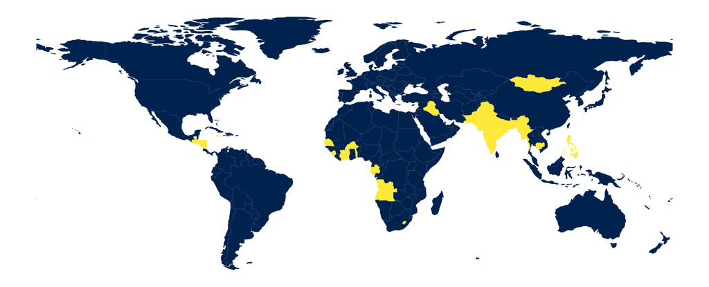

```python
print ('Pays pour lesquels la proportion de personnes sous alimentées est supérieure à 10% malgré une disponibilité alimentaire de plus de 2400 kcal par personne et par jour, 2013 ')
world.plot(column='dispoal_sup_2400_sousnut_sup_10%', cmap='cividis', figsize=(20, 20)).axis('off')
plt.show()
```

## Aide alimentaire et disponibilité alimentaire (Kcal/personne/jour), 2013

```python
aide_alimentaire_vs_dispo_alimentaire_2013= pd.merge(aide_alimentaire_2013, calories_2013_perperson_perday_perzone, on = "Zone", how = 'inner')
```

```python
aide_alimentaire_vs_dispo_alimentaire_2013.sort_values(by = "Aide alimentaire (tonnes)", ascending = False)
```

|  | Zone | Aide alimentaire (tonnes) | Disponibilité alimentaire (Kcal/personne/jour) |
| --- | --- | --- | --- |
| 0 | Éthiopie | 591404 | 2129.0 |
| 1 | Soudan | 330230 | 2335.0 |
| 2 | Yémen | 264764 | 2217.0 |
| 3 | Kenya | 220966 | 2205.0 |
| 4 | Bangladesh | 131018 | 2453.0 |
| ... | ... | ... | ... |
| 58 | Tadjikistan | 746 | 2199.0 |
| 59 | Iraq | 666 | 2542.0 |
| 60 | Zambie | 328 | 1924.0 |
| 61 | Timor-Leste | 116 | 2129.0 |
| 62 | Géorgie | 34 | 2902.0 |

63 rows × 3 columns

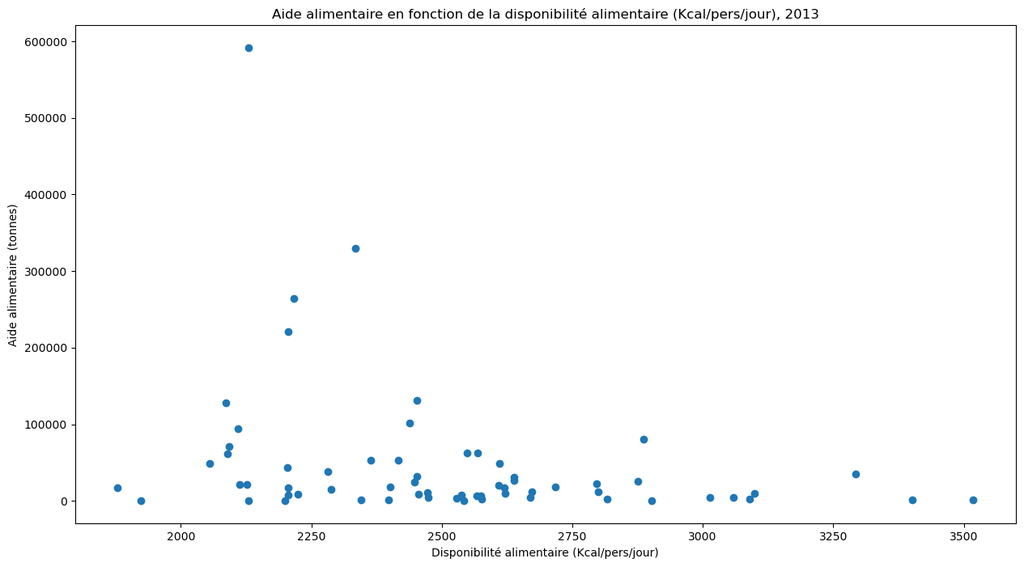

```python
fig = plt.figure(figsize = (15,8))
ax = fig.add_subplot()
ax.scatter(aide_alimentaire_vs_dispo_alimentaire_2013["Disponibilité alimentaire (Kcal/personne/jour)"], aide_alimentaire_vs_dispo_alimentaire_2013["Aide alimentaire (tonnes)"])
ax.set_xlabel("Disponibilité alimentaire (Kcal/pers/jour)")
ax.set_ylabel("Aide alimentaire (tonnes)")
ax.set_title("Aide alimentaire en fonction de la disponibilité alimentaire (Kcal/pers/jour), 2013")
plt.show()
```

```python
aide_alimentaire_vs_dispo_alimentaire_2013[aide_alimentaire_vs_dispo_alimentaire_2013["Zone"] == "Pakistan"]
```

|  | Zone | Aide alimentaire (tonnes) | Disponibilité alimentaire (Kcal/personne/jour) |
| --- | --- | --- | --- |
| 6 | Pakistan | 101364 | 2438.0 |

## Pays pour lesquels la proportion de personnes en état de sous alimentation s'aggrave

utilisation des df proportion_personnes_sous_alimentées_2013_par_pays et insecurite_alimentaire_population_2017_merge, merge, création d'une colonne taux d'évolution, filtre sur les valeurs proportion personnes sous alimentées 2013 > 0.10 et taux d'évolution supérieur à 10%

```python
proportion_personnes_sous_alimentées_2013_par_pays = proportion_personnes_sous_alimentées_2013_par_pays.rename(columns = {"Population" : "Population 2013"})
proportion_personnes_sous_alimentées_2013_par_pays = proportion_personnes_sous_alimentées_2013_par_pays.rename(columns = {"Nbr de personnes sous-alimentées" : "Nbr de personnes sous-alimentées 2013"})
proportion_personnes_sous_alimentées_2013_par_pays = proportion_personnes_sous_alimentées_2013_par_pays.rename(columns = {"Proportion de personnes sous alimentées" : "Proportion de personnes sous alimentées 2013"})
```

```python
proportion_personnes_sous_alimentées_2017vs2013_par_pays = pd.merge(proportion_personnes_sous_alimentées_2013_par_pays.drop(columns="Année"), insecurite_alimentaire_population_2017_merge.dropna(), on = "Zone", how = 'inner')
proportion_personnes_sous_alimentées_2017vs2013_par_pays
```

|  | Zone | Population 2013 | Nbr de personnes sous-alimentées 2013 | Proportion de personnes sous alimentées 2013 | Personnes_sous_alimentées_2017 | Population_2017 | Proportion_personnes_sous_alimentées_2017 |
| --- | --- | --- | --- | --- | --- | --- | --- |
| 0 | Afghanistan | 32269589.0 | 8600000.0 | 0.266505 | 10500000.0 | 36296113.0 | 0.289287 |
| 1 | Afrique du Sud | 53687121.0 | 2200000.0 | 0.040978 | 3100000.0 | 57009756.0 | 0.054377 |
| 2 | Albanie | 2903790.0 | 100000.0 | 0.034438 | 100000.0 | 2884169.0 | 0.034672 |
| 3 | Algérie | 38140133.0 | 1300000.0 | 0.034085 | 1300000.0 | 41389189.0 | 0.031409 |
| 4 | Angola | 26015781.0 | 7600000.0 | 0.292130 | 5800000.0 | 29816766.0 | 0.194521 |
| ... | ... | ... | ... | ... | ... | ... | ... |
| 78 | Timor-Leste | 1153294.0 | 400000.0 | 0.346833 | 400000.0 | 1243258.0 | 0.321735 |
| 79 | Togo | 6954722.0 | 1500000.0 | 0.215681 | 1600000.0 | 7698474.0 | 0.207833 |
| 80 | Turkménistan | 5366378.0 | 300000.0 | 0.055904 | 200000.0 | 5757667.0 | 0.034736 |
| 81 | Venezuela (République bolivarienne du) | 29781040.0 | 1400000.0 | 0.047010 | 8000000.0 | 29402484.0 | 0.272086 |
| 82 | Viet Nam | 90752592.0 | 8900000.0 | 0.098069 | 6500000.0 | 94600648.0 | 0.068710 |

83 rows × 7 columns

```python
proportion_personnes_sous_alimentées_2017vs2013_par_pays["Taux evolution proportion de personnes sous alimentées(%)"] = round((proportion_personnes_sous_alimentées_2017vs2013_par_pays["Proportion_personnes_sous_alimentées_2017"]-proportion_personnes_sous_alimentées_2017vs2013_par_pays["Proportion de personnes sous alimentées 2013"])/proportion_personnes_sous_alimentées_2017vs2013_par_pays["Proportion de personnes sous alimentées 2013"]*100)
```

```python
proportion_personnes_sous_alimentées_2017vs2013_par_pays= proportion_personnes_sous_alimentées_2017vs2013_par_pays.sort_values(by = "Taux evolution proportion de personnes sous alimentées(%)", ascending = False)
```

```python
print("Pays pour lesquels la proportion de personnes en état de sous alimentation est supérieure  à 10% et s'aggrave fortement entre 2013-2017")
```

```
Pays pour lesquels la proportion de personnes en état de sous alimentation est supérieure  à 10% et s'aggrave fortement entre 2013-2017
```

```python
proportion_personnes_sous_alimentées_2017vs2013_par_pays[(proportion_personnes_sous_alimentées_2017vs2013_par_pays["Taux evolution proportion de personnes sous alimentées(%)"]>=10) & (proportion_personnes_sous_alimentées_2017vs2013_par_pays["Proportion de personnes sous alimentées 2013"]>=0.10)]
```

|  | Zone | Population 2013 | Nbr de personnes sous-alimentées 2013 | Proportion de personnes sous alimentées 2013 | Personnes_sous_alimentées_2017 | Population_2017 | Proportion_personnes_sous_alimentées_2017 | Taux evolution proportion de personnes sous alimentées(%) |
| --- | --- | --- | --- | --- | --- | --- | --- | --- |
| 42 | Lesotho | 2028530.0 | 300000.0 | 0.147890 | 800000.0 | 2091534.0 | 0.382494 | 159.0 |
| 53 | Mozambique | 25560755.0 | 5900000.0 | 0.230823 | 9400000.0 | 28649018.0 | 0.328109 | 42.0 |
| 69 | Rwanda | 10811538.0 | 2800000.0 | 0.258983 | 4200000.0 | 11980961.0 | 0.350556 | 35.0 |
| 28 | Gambie | 1963712.0 | 200000.0 | 0.101848 | 300000.0 | 2213889.0 | 0.135508 | 33.0 |
| 45 | Madagascar | 22961255.0 | 7600000.0 | 0.330992 | 10500000.0 | 25570512.0 | 0.410629 | 24.0 |
| 10 | Botswana | 2062548.0 | 400000.0 | 0.193935 | 500000.0 | 2205080.0 | 0.226749 | 17.0 |
| 67 | République populaire démocratique de Corée | 24929497.0 | 10300000.0 | 0.413165 | 12000000.0 | 25429825.0 | 0.471887 | 14.0 |
| 52 | Mongolie | 2881791.0 | 500000.0 | 0.173503 | 600000.0 | 3113786.0 | 0.192691 | 11.0 |
| 47 | Malawi | 15839286.0 | 2700000.0 | 0.170462 | 3300000.0 | 17670196.0 | 0.186755 | 10.0 |